# __FLIGHT CANCELLATION PREDICTION__

**The Problem**

Predicting Cancellation of Domestic Flights in the USA. Flight cancellation is a rare event but a big concern for many people/organization. Because if you have a flight, most probably all other your plans will be based on your arrival to the destination. Assume you have a holiday plan in LA, you booked your hotel, you rented your car, you made a reservation for an activity etc. But when you arrive the EWX airport you released that your flight is cancelled. Then you have to alter all your plans due to this unexpexted rare event . It is needless to say you would have taken necessary precautions if you had known your flight’s cancellation in advance. Definitely there are many factors which may result in those cancellations such as origin and destination airport location, airline company, time of flight etc. In this study we will propose a model to predict flight cancellations for US domestic flights at 20 most used airports in the USA.

**Who Might Care :**

__a. Travellers :__ Flight cancellations have a huge impact on whoever will have a flight trip, so travellers definitely can care cancellations.

__b. Travel Planners :__ Some organization companies like tourism agency make plan for their organizations. For instance they sell cultural/historical or holiday travel package. If their flight cancelled then they may have encounter big problems. In this context, they also care about flight cancellation prediction.

__c. Online Booking Companies :__ Booking.com, Kayak.com, Skyscanner.com are top online flight ticket selling companies. Cancelled flights will defintely affect their business negatively. If they known in advace/ predict cancellations they can inform their customers to take precaution against the problem which may stem from flight cancellation.

__d. Airline Companies :__ Airline companies may suffer from cancellation very much. If they have relatively higher cancellation rates they may have a customer churn problem. In order to avoid this problem they aslo care it.

__e. Hotels :__ Even hotels, espacially located nearby airports (destination) may be affected by cancelled flights. They may show interest on predicting cancelled flighs.

All those shareholders may be affected because of flight cancellations. To minimize the negative effect of cancellation by predicting those cancellations we will build some ML algortihms.

**Data Set :**

a. The data has been obtained from the "Bureau of Transportation Statisitcs" (https://www.transtats.bts.gov/DL_SelectFields.asp?Table_ID=236&DB_Short_Name=On-Time.) which allows to download the flight data monthly at a time. This data contains information about flights and their on-time performance, including date of flight, carrier company, origin and destination airports, flight duration, flight distance, delay, cancellation, diversion etc.

b. The dataset has 2798209 observations/rows as well as 110 features/columns.

c. The data seems raw. It has too many missing values in addition to some outliers.

d. The data is not fictitious but real, and belongs to first half of 2017.

e. Target Feature is 'Cancelled'. Since it takes 1 for cancelled flights and 0 for non-cancelled flights, so it is binary.

f. Although the flight cancellations may results from bad weather conditions as well, in this study weather conditions will not be in our scope.

**Machine Learning Aspect**

1. We have labeled data and target fetaure is a binary variable so this is a classification problem.

2. We will use Logistic Regression, K-NN Neighbor, Random Forest, Adaboost and Gradient Bosoting algorithms to solve the problem

3. My dependent feature will be Cancelled column and take 1 for cancelled flights and 0 for non-cancelled flights

4. My independet features will be Origin Airport **[Origin]**, Destination Airport **[Dest]**, Scheduled Flight Time **[CRSElaspedTime]**, Taxi Out (total time on gateway before taking off) Duration **[TaxiOut]**, what part of the month the flight will occur (first 2 weeks or latter 2 weeks) **[PartOfMonth]**, when the flights occur (weekdays or weekends) **[PartOfWeek]** and what part of the day (night, daytime or morning hours) **[PartOfDay]** would the flight happen, Departure Delay Minutes **[DepDelayMinutes]** and Airline Company **[Carrier]** in my model.

5. I will use 80% of my data as train set and 20% or my data as test set and I will split my data at the very beginnig of my study. All data cleansing preocess and EDA Analysis will be implement on train data set. Test data set will be manipulated with regard to train data set before ML implementation and later it will be used only in ML algorithms to evaluate how our ML models' performance.

**What are my deliverables? :**

I will complete this project on **Jupiter Notebook**. First I will examine data, then wrangle the data and apply ML algorithms. Hopefully I will have learned the basic concepts of data science (Wrangling, Story Telling (EDA) and ML)

a. Data Collection

b. Data Wrangling

c. EDA (Exploratory Data Analysis)

d. Modeling

e. Presentation

# IMPORTS

We will use the standard data science and machine learning libraries: `numpy`, `pandas`, and `scikit-learn`. We also use `matplotlib` and `seaborn` for visualization.

```python
# Pandas and numpy for data manipulation
import pandas as pd
import numpy as np
% pylab inline

# No warnings about setting value on copy of slice
pd.options.mode.chained_assignment = None

# Matplotlib visualization
import matplotlib.pyplot as plt
import matplotlib.colors as colors
from matplotlib.colors import ListedColormap
%matplotlib inline
from pylab import rcParams

# Set default font size
plt.rcParams['font.size'] = 24

# Internal ipython tool for setting figure size
from IPython.core.pylabtools import figsize

# Seaborn for visualization
import seaborn as sns
sns.set(font_scale = 2)

# Splitting data into training and testing
from sklearn.model_selection import train_test_split

## Datetime Process
from datetime import datetime, date, timedelta, time
```

# SETTING DATAFRAME DISPLAY

```python
# Display all columns of the dataframe
pd.set_option('display.width', 800)
pd.set_option('display.max_columns', 300)
pd.set_option('display.notebook_repr_html', True)
pd.options.display.max_colwidth = 100
```

# LOADING DATA

```python
## Reading file as merged
merged = pd.read_csv('merged_flight_data.csv')
```

```python
merged.shape
```

```
(706981, 47)
```

```python
merged.head(3)
```

|  | Unnamed: 0 | Year | Quarter | Month | DayofMonth | DayOfWeek | FlightDate | Carrier | Origin | OriginCityName | OriginState | Dest | DestCityName | DestState | CRSDepTime | DepTime | DepDelay | DepDelayMinutes | DepDel15 | DepartureDelayGroups | DepTimeBlk | TaxiOut | WheelsOff | WheelsOn | TaxiIn | CRSArrTime | ArrTime | ArrDelay | ArrDelayMinutes | … |
| --- | --- | --- | --- | --- | --- | --- | --- | --- | --- | --- | --- | --- | --- | --- | --- | --- | --- | --- | --- | --- | --- | --- | --- | --- | --- | --- | --- | --- | --- | --- |
| 0 | 0 | 2017 | 1 | 1 | 17 | 2 | 2017-01-17 | AA | CLT | Charlotte, NC | NC | PHX | Phoenix, AZ | AZ | 1619 | 1616.0 | -3.0 | 0.0 | 0.0 | -1.0 | 1600-1659 | 17.0 | 1633.0 | 1837.0 | 5.0 | 1856 | 1842.0 | -14.0 | 0.0 | … |
| 1 | 1 | 2017 | 1 | 1 | 18 | 3 | 2017-01-18 | AA | CLT | Charlotte, NC | NC | PHX | Phoenix, AZ | AZ | 1619 | 1614.0 | -5.0 | 0.0 | 0.0 | -1.0 | 1600-1659 | 13.0 | 1627.0 | 1815.0 | 6.0 | 1856 | 1821.0 | -35.0 | 0.0 | … |
| 2 | 2 | 2017 | 1 | 1 | 19 | 4 | 2017-01-19 | AA | CLT | Charlotte, NC | NC | PHX | Phoenix, AZ | AZ | 1619 | 1611.0 | -8.0 | 0.0 | 0.0 | -1.0 | 1600-1659 | 17.0 | 1628.0 | 1824.0 | 2.0 | 1856 | 1826.0 | -30.0 | 0.0 | … |

```python
## Droping an unnecessary very first column
merged.drop(['Unnamed: 0'], axis=1, inplace=True)
```

# DATA TYPES AND MISSING VALUES

```python
merged.info()
```

```
<class 'pandas.core.frame.DataFrame'>
RangeIndex: 706981 entries, 0 to 706980
Data columns (total 46 columns):
Year                    706981 non-null int64
Quarter                 706981 non-null int64
Month                   706981 non-null int64
DayofMonth              706981 non-null int64
DayOfWeek               706981 non-null int64
FlightDate              706981 non-null object
Carrier                 706981 non-null object
Origin                  706981 non-null object
OriginCityName          706981 non-null object
OriginState             706981 non-null object
Dest                    706981 non-null object
DestCityName            706981 non-null object
DestState               706981 non-null object
CRSDepTime              706981 non-null int64
DepTime                 698164 non-null float64
DepDelay                698159 non-null float64
DepDelayMinutes         698159 non-null float64
DepDel15                698159 non-null float64
DepartureDelayGroups    698159 non-null float64
DepTimeBlk              706981 non-null object
TaxiOut                 697926 non-null float64
WheelsOff               697926 non-null float64
WheelsOn                697782 non-null float64
TaxiIn                  697782 non-null float64
CRSArrTime              706981 non-null int64
ArrTime                 697782 non-null float64
ArrDelay                696522 non-null float64
ArrDelayMinutes         696522 non-null float64
ArrDel15                696522 non-null float64
ArrivalDelayGroups      696522 non-null float64
ArrTimeBlk              706981 non-null object
Cancelled               706981 non-null float64
CancellationCode        9078 non-null object
CRSElapsedTime          706980 non-null float64
ActualElapsedTime       696522 non-null float64
AirTime                 696522 non-null float64
Distance                706981 non-null float64
CarrierDelay            158913 non-null float64
WeatherDelay            158913 non-null float64
NASDelay                158913 non-null float64
SecurityDelay           158913 non-null float64
LateAircraftDelay       158913 non-null float64
FirstDepTime            4913 non-null float64
TotalAddGTime           4913 non-null float64
LongestAddGTime         4913 non-null float64
Company                 706981 non-null object
dtypes: float64(27), int64(7), object(12)
memory usage: 248.1+ MB
```

The **dataframe.info** method is a quick way to assess the data by displaying the data types of each column and the number of non-missing values. When we check, we see that some date informations stored as object(string) in our dataset such as FlightDate so we need to **convert those into correct data type**. Additionally, some columns have missing values. But before handling the missing values we will consider whether relevant column worth to be in our **cancellation prediction analysis** or it is completely irrelevant, if so we will drop them without filling.

```python
listA = list(merged.columns)
listB = list(merged.isnull().sum())
c= round((merged.isnull().sum()/len(merged)*100),2)

dfisNull = pd.DataFrame({'isNullNo':listB,'isnullRatio':c, 'Value_Counts':[merged[col].nunique() for col in merged.columns],
                        'Type':[merged[col].dtypes for col in merged.columns]})

dfisNull.T
```

|  | Year | Quarter | Month | DayofMonth | DayOfWeek | FlightDate | Carrier | Origin | OriginCityName | OriginState | Dest | DestCityName | DestState | CRSDepTime | DepTime | DepDelay | DepDelayMinutes | DepDel15 | DepartureDelayGroups | DepTimeBlk | TaxiOut | WheelsOff | WheelsOn | TaxiIn | CRSArrTime | ArrTime | ArrDelay | ArrDelayMinutes | ArrDel15 | … |
| --- | --- | --- | --- | --- | --- | --- | --- | --- | --- | --- | --- | --- | --- | --- | --- | --- | --- | --- | --- | --- | --- | --- | --- | --- | --- | --- | --- | --- | --- | --- |
| Type | int64 | int64 | int64 | int64 | int64 | object | object | object | object | object | object | object | object | int64 | float64 | float64 | float64 | float64 | float64 | object | float64 | float64 | float64 | float64 | int64 | float64 | float64 | float64 | float64 | … |
| Value_Counts | 1 | 2 | 6 | 31 | 7 | 181 | 11 | 20 | 20 | 17 | 20 | 20 | 17 | 1210 | 1414 | 883 | 852 | 2 | 15 | 19 | 167 | 1417 | 1440 | 160 | 1339 | 1440 | 937 | 856 | 2 | … |
| isNullNo | 0 | 0 | 0 | 0 | 0 | 0 | 0 | 0 | 0 | 0 | 0 | 0 | 0 | 0 | 8817 | 8822 | 8822 | 8822 | 8822 | 0 | 9055 | 9055 | 9199 | 9199 | 0 | 9199 | 10459 | 10459 | 10459 | … |
| isnullRatio | 0 | 0 | 0 | 0 | 0 | 0 | 0 | 0 | 0 | 0 | 0 | 0 | 0 | 0 | 1.25 | 1.25 | 1.25 | 1.25 | 1.25 | 0 | 1.28 | 1.28 | 1.3 | 1.3 | 0 | 1.3 | 1.48 | 1.48 | 1.48 | … |

# FIXING DATETIME FORMAT

We have __FlightDate__ and __CRSDepTime (Scheduled Departure Time)__, __CRSArrTime (Scheduled Arrival Time)__ columns with date and time information in our dataframe. First we will convert FlightDate to __datetime object__ and then we will create `FlightDate_Dest` because date may change when the airplane lands on the destination due to time zone difference and flight duration. Then we will create a flight DATETIME at origin (`FlightDateTime_Origin`) and destination (`FlightDateTime_Dest`)

```python
## Changing FlightDate column to datetime object
merged.FlightDate = pd.to_datetime(merged.FlightDate)
```

```python
def create_datetime_column(date_column, time_column):
    '''This function creates new datetime of flights columns at Origin and Destination'''

    new_col = list()
    time_column[(time_column == 2400)] = 0
    for row in range(len(date_column)):
        temp_Date = date_column[row]
        temp_Time = time_column[row]
        temp_TimeFormatted = datetime.strptime(str(temp_Time).zfill(4), "%H%M")
        temp_Hour = temp_TimeFormatted.hour
        temp_Min = temp_TimeFormatted.minute
        new_col.append(temp_Date + pd.DateOffset(hour = temp_Hour, minute = temp_Min))
    return new_col
```

```python
## Creating new FligtDateTime_Origin column from FlightDate and CRSDepTime columns
merged['FlightDateTime_Origin'] = create_datetime_column(merged.FlightDate, merged.CRSDepTime)
```

```python
## Creating a new column for the Destination the Date is being checked whether changing or not at Destination due to time zone and flight elapsed time
merged["FlightDate_Dest"] = np.where((merged.CRSArrTime - merged.CRSDepTime) > 0,
                                    pd.DatetimeIndex(merged.FlightDate) + pd.DateOffset(0),
                                    pd.DatetimeIndex(merged.FlightDate) + pd.DateOffset(1))
```

```python
merged[["FlightDate", "Origin", "Dest", "CRSDepTime", "CRSArrTime", "FlightDate_Dest"]][merged.CRSDepTime > 2300].head(10) ## To show the date change at the destination we chose 2300 as a flight start time.
```

|  | FlightDate | Origin | Dest | CRSDepTime | CRSArrTime | FlightDate_Dest |
| --- | --- | --- | --- | --- | --- | --- |
| 175 | 2017-01-02 | PHX | SEA | 2340 | 144 | 2017-01-03 |
| 176 | 2017-01-03 | PHX | SEA | 2340 | 144 | 2017-01-04 |
| 1923 | 2017-01-14 | SEA | CLT | 2359 | 749 | 2017-01-15 |
| 1930 | 2017-01-21 | SEA | CLT | 2359 | 749 | 2017-01-22 |
| 1937 | 2017-01-28 | SEA | CLT | 2359 | 749 | 2017-01-29 |
| 2987 | 2017-01-01 | SFO | ORD | 2355 | 603 | 2017-01-02 |
| 2988 | 2017-01-02 | SFO | ORD | 2355 | 603 | 2017-01-03 |
| 2989 | 2017-01-03 | SFO | ORD | 2355 | 603 | 2017-01-04 |
| 2990 | 2017-01-04 | SFO | ORD | 2355 | 603 | 2017-01-05 |
| 2991 | 2017-01-05 | SFO | ORD | 2355 | 603 | 2017-01-06 |

As seen from the above table, flight date is changing at destiantion.

```python
## To create FlightDateTime_Dest form FlightDate and CRSArrTime columns
merged['FlightDateTime_Dest'] = create_datetime_column(merged.FlightDate_Dest, merged.CRSArrTime)
```

```python
merged['Flight_Hour'] = merged.FlightDateTime_Origin.dt.hour
```

# CHANGING DATA TYPE

```python
## Float type of Cancelled column converted into integer
merged.Cancelled = merged.Cancelled.astype(int)
```

**Adding Some Extra Information to DataFrame**

```python
##  Adding Month Name
month_dict={
    1:  '01-January',
    2:  '02-February',
    3:  '03-March',
    4:  '04-April',
    5:  '05-May',
    6:  '06-June',
    7:  '07-July',
    8:  '08-August',
    9:  '09-September',
    10: '10-October',
    11: '11-November',
    12: '12-December'
}
merged['MonthName'] = merged['Month'].map(lambda m: month_dict[m])

## Adding Day of the week name
dow_dict = {
    1: 'Monday',
    2: 'Tuesday',
    3: 'Wednesday',
    4: 'Thursday',
    5: 'Friday',
    6: 'Saturday',
    7: 'Sunday'
}
merged['DayOfWeekName'] = merged['DayOfWeek'].map(lambda d:dow_dict[d])
```

# SPLITTING TRAIN AND TEST SET

```python
from sklearn.model_selection import train_test_split

train_set, test_set = train_test_split(merged, test_size=0.2, random_state=33)
print(train_set.shape)
print(test_set.shape)
#X = merged.drop(['Cancelled'], axis=1) ## Train set
#y = pd.DataFrame(merged.Cancelled)
```

```
(565584, 52)
(141397, 52)
```

`80%` of data is `train_set` & `20%` of data is hold as `test_set`

```python
test_set.reset_index(drop=True).head()
```

|  | Year | Quarter | Month | DayofMonth | DayOfWeek | FlightDate | Carrier | Origin | OriginCityName | OriginState | Dest | DestCityName | DestState | CRSDepTime | DepTime | DepDelay | DepDelayMinutes | DepDel15 | DepartureDelayGroups | DepTimeBlk | TaxiOut | WheelsOff | WheelsOn | TaxiIn | CRSArrTime | ArrTime | ArrDelay | ArrDelayMinutes | ArrDel15 | … |
| --- | --- | --- | --- | --- | --- | --- | --- | --- | --- | --- | --- | --- | --- | --- | --- | --- | --- | --- | --- | --- | --- | --- | --- | --- | --- | --- | --- | --- | --- | --- |
| 0 | 2017 | 1 | 1 | 26 | 4 | 2017-01-26 | B6 | MCO | Orlando, FL | FL | LAX | Los Angeles, CA | CA | 1903 | 1956.0 | 53.0 | 53.0 | 1.0 | 3.0 | 1900-1959 | 23.0 | 2019.0 | 2259.0 | 13.0 | 2137 | 2312.0 | 95.0 | 95.0 | 1.0 | … |
| 1 | 2017 | 1 | 2 | 25 | 6 | 2017-02-25 | DL | FLL | Fort Lauderdale, FL | FL | DTW | Detroit, MI | MI | 1806 | 1757.0 | -9.0 | 0.0 | 0.0 | -1.0 | 1800-1859 | 18.0 | 1815.0 | 2043.0 | 9.0 | 2114 | 2052.0 | -22.0 | 0.0 | 0.0 | … |
| 2 | 2017 | 1 | 1 | 16 | 1 | 2017-01-16 | DL | SEA | Seattle, WA | WA | MCO | Orlando, FL | FL | 2245 | 2330.0 | 45.0 | 45.0 | 1.0 | 3.0 | 2200-2259 | 22.0 | 2352.0 | 740.0 | 6.0 | 711 | 746.0 | 35.0 | 35.0 | 1.0 | … |
| 3 | 2017 | 1 | 3 | 8 | 3 | 2017-03-08 | UA | BOS | Boston, MA | MA | EWR | Newark, NJ | NJ | 800 | 754.0 | -6.0 | 0.0 | 0.0 | -1.0 | 0800-0859 | 11.0 | 805.0 | 857.0 | 17.0 | 930 | 914.0 | -16.0 | 0.0 | 0.0 | … |
| 4 | 2017 | 1 | 3 | 5 | 7 | 2017-03-05 | OO | SFO | San Francisco, CA | CA | MSP | Minneapolis, MN | MN | 1806 | 1758.0 | -8.0 | 0.0 | 0.0 | -1.0 | 1800-1859 | 15.0 | 1813.0 | 2317.0 | 9.0 | 2359 | 2326.0 | -33.0 | 0.0 | 0.0 | … |

# HANDLING WITH MISSING VALUES

```python
# Function to calculate missing values by column
def missing_values_table(df):
        # Total missing values
        mis_val = df.isnull().sum()

        # Percentage of missing values
        mis_val_percent = 100 * df.isnull().sum() / len(df)

        # Make a table with the results
        mis_val_table = pd.concat([mis_val, mis_val_percent], axis=1)

        # Rename the columns
        mis_val_table_ren_columns = mis_val_table.rename(
        columns = {0 : 'Missing Values', 1 : '% of Total Values'})

        # Sort the table by percentage of missing descending
        mis_val_table_ren_columns = mis_val_table_ren_columns[
            mis_val_table_ren_columns.iloc[:,1] != 0].sort_values(
        '% of Total Values', ascending=False).round(1)

        # Print some summary information
        print ("Your selected dataframe has " + str(df.shape[1]) + " columns.\n"
            "There are " + str(mis_val_table_ren_columns.shape[0]) +
              " columns that have missing values.")

        # Return the dataframe with missing information
        return mis_val_table_ren_columns
```

```python
missing_values_table(train_set)
```

```
Your selected dataframe has 52 columns.
There are 25 columns that have missing values.
```

|  | Missing Values | % of Total Values |
| --- | --- | --- |
| LongestAddGTime | 561633 | 99.3 |
| TotalAddGTime | 561633 | 99.3 |
| FirstDepTime | 561633 | 99.3 |
| CancellationCode | 558285 | 98.7 |
| LateAircraftDelay | 438493 | 77.5 |
| SecurityDelay | 438493 | 77.5 |
| NASDelay | 438493 | 77.5 |
| WeatherDelay | 438493 | 77.5 |
| CarrierDelay | 438493 | 77.5 |
| ArrivalDelayGroups | 8414 | 1.5 |
| AirTime | 8414 | 1.5 |
| ActualElapsedTime | 8414 | 1.5 |
| ArrDel15 | 8414 | 1.5 |
| ArrDelayMinutes | 8414 | 1.5 |
| ArrDelay | 8414 | 1.5 |
| ArrTime | 7402 | 1.3 |
| TaxiIn | 7402 | 1.3 |
| WheelsOn | 7402 | 1.3 |
| WheelsOff | 7280 | 1.3 |
| TaxiOut | 7280 | 1.3 |
| DepDelay | 7100 | 1.3 |
| DepartureDelayGroups | 7100 | 1.3 |
| DepDel15 | 7100 | 1.3 |
| DepDelayMinutes | 7100 | 1.3 |
| DepTime | 7100 | 1.3 |

Although we want to be careful to not discard information and should be careful when dropping columns, if a column has a high percentage of missing values, then it probably will not be of much use. Before starting filling the missing values some columns have more than 50% missing values and they don't give us much information so we will dorp them.

```python
dropped_columns = list()
```

**Dropping Columns with More Than 50% Missing Values**

```python
# Get the columns with > 50% missing
missing_df = missing_values_table(train_set);
missing_columns = list(missing_df[missing_df['% of Total Values'] > 50].index)
print('We will remove %d columns.' % len(missing_columns))
```

```
Your selected dataframe has 52 columns.
There are 25 columns that have missing values.
We will remove 9 columns.
```

```python
# We will add those columns to drop later
dropped_columns = dropped_columns + list(missing_columns)
```

TotalAddGTime, LongestAddGTime, FirstDepTime, CancellationCode, LateAirCraftDelay, SecurityDelay, NASDelay, CarrierDelay, WeatherDelay columns will be dropped

__Checking Duplicating Values__

```python
print(train_set.duplicated().sum())
```

```
0
```

There is no dublicating value in our dataset. It is good.

```python
time_columns = ['CRSDepTime','DepTime','DepDelay', 'DepDelayMinutes','TaxiOut', 'WheelsOff', 'WheelsOn','TaxiIn','CRSArrTime','ArrTime','ArrDelay',
                'ArrDelayMinutes','CRSElapsedTime', 'ActualElapsedTime', 'AirTime', 'Cancelled']
```

**DepDel15, DepDelay, DepartureDelayGroups (Depature Delay Informations)**

Those columns also give us information linked with `DepDelayMinutes` so we can drop those columns.

```python
dropped_columns.extend(['DepDel15', 'DepartureDelayGroups', 'DepDelay'])
```

**DepDelayMinutes (Departure Delay)**

Departure Delay shows flight delays in minutes. We will get mean of Cancelled flights to fill missing values for Cancelled flights.

```python
train_set[train_set['Cancelled']==1]['DepDelayMinutes'].isnull().sum()
```

```
7100
```

As wee see, all missing DepDelayMinutes belongs to cancelled flights. We can get the `mean of DepDelayMinutes` of cancelled flight and impute the missing values with it

```python
DepDelayMinutes_fill = train_set[train_set['Cancelled']==1]['DepDelayMinutes'].mean()
DepDelayMinutes_fill
```

```
94.37185929648241
```

```python
train_set['DepDelayMinutes'] = train_set['DepDelayMinutes'].fillna(DepDelayMinutes_fill)
```

```python
train_set['DepDelayMinutes'].isnull().sum()
```

```
0
```

We have no missing value for DepDelayMinutes anymore

**WheelsOff, WheelsOn, TaxiIn, AirTime, ArrTime, ArrDelayMinutes, ArrDel15, ArrivalDelayGroups, ActualElapsedTime, CRSDepTime, CRSArrTime**

Those columns also give us information regarding `actual happened flights` so they are not related to predict cancellation, too. We can __drop__ those columns.

```python
## We can drop those columns
dropped_columns.extend(['ActualElapsedTime','AirTime', 'WheelsOff', 'WheelsOn', 'TaxiIn', 'ArrTime','ArrDelayMinutes', 'ArrDel15', 'ArrivalDelayGroups', 'CRSDepTime','CRSArrTime'])
```

**TaxiOut**

TaxiOut shows elapsed time in minutes on the gateway before taking off delays in minutes. Some flights may have cancelled after the airliner spend some time on gateway. We will get `mean of TaxiOut time` for Cancelled flights to fill missing values for Cancelled flights.

```python
train_set[train_set['Cancelled']==1]['TaxiOut'].isnull().sum()
```

```
7280
```

All missing values belong to Cancelled flights

```python
TaxiOut_fill = train_set[train_set['Cancelled']==1]['TaxiOut'].mean()
TaxiOut_fill
```

```
28.263157894736842
```

```python
train_set['TaxiOut'] = train_set['TaxiOut'].fillna(TaxiOut_fill)
```

```python
train_set[train_set['Cancelled']==1]['TaxiOut'].isnull().sum()
```

```
0
```

We have no missing value for TaxiOut anymore

**CRSElapseTime**

We have `1 missing value` in this column. We can drop this row.

```python
test_set.CRSElapsedTime.isnull().sum()
```

```
1
```

```python
## We discard the single missing value row of CRSElaspsedTime
test_set = test_set[~pd.isnull(test_set.CRSElapsedTime)]
```

```python
train_set.reset_index(drop=True).head(2)
```

|  | Year | Quarter | Month | DayofMonth | DayOfWeek | FlightDate | Carrier | Origin | OriginCityName | OriginState | Dest | DestCityName | DestState | CRSDepTime | DepTime | DepDelay | DepDelayMinutes | DepDel15 | DepartureDelayGroups | DepTimeBlk | TaxiOut | WheelsOff | WheelsOn | TaxiIn | CRSArrTime | ArrTime | ArrDelay | ArrDelayMinutes | ArrDel15 | … |
| --- | --- | --- | --- | --- | --- | --- | --- | --- | --- | --- | --- | --- | --- | --- | --- | --- | --- | --- | --- | --- | --- | --- | --- | --- | --- | --- | --- | --- | --- | --- |
| 0 | 2017 | 1 | 3 | 30 | 4 | 2017-03-30 | VX | SFO | San Francisco, CA | CA | LAX | Los Angeles, CA | CA | 800 | 756.0 | -4.0 | 0.0 | 0.0 | -1.0 | 0800-0859 | 41.0 | 837.0 | 932.0 | 6.0 | 925 | 938.0 | 13.0 | 13.0 | 0.0 | … |
| 1 | 2017 | 2 | 4 | 2 | 7 | 2017-04-02 | UA | DTW | Detroit, MI | MI | DEN | Denver, CO | CO | 1535 | 1533.0 | -2.0 | 0.0 | 0.0 | -1.0 | 1500-1559 | 11.0 | 1544.0 | 1631.0 | 8.0 | 1653 | 1639.0 | -14.0 | 0.0 | 0.0 | … |

**Year**

Year information is the same for all rows so it does not give us any spesific information. We can drop it.

```python
dropped_columns.extend(['Year'])
#merged.drop(['Year'], axis=1, inplace=True)
```

**OriginCityName, OriginState, DestCityName, DestState**

We have already location information for both Origin and Destination. So those are redundant information and we can drop them.

```python
dropped_columns.extend(['OriginCityName', 'OriginState', 'DestCityName', 'DestState'])
#merged.drop(['OriginCityName', 'OriginState', 'DestCityName', 'DestState'], axis=1, inplace=True)
```

**DepTimeBlk, ArrTimeBlk (Departure Time Block, Arrival Time Block)**

Those columns does not give us any spesific information as well. We can drop them too.

```python
dropped_columns.extend(['DepTimeBlk', 'ArrTimeBlk'])
#merged.drop(['DepTimeBlk', 'ArrTimeBlk'], axis=1, inplace=True)
```

**DepDelay (Departure Delay)**

It is linked with `DepDelayMinutes` and we will keep DepDelayMinutes so we will drop it.

```python
dropped_columns.extend(['DepDelay'])
#merged.drop(['DepDelay'], axis=1, inplace=True)
```

**DepTime (Departure Time)**

We have created `FlightDateTime_Origin` column contains the same information so we can drop it

```python
dropped_columns.extend(['DepTime'])
#merged.drop(['DepTime'], axis=1, inplace=True)
```

**ArrDelay (Arrival Delay)**

It happens in case of non-Cancelled flight and there is no data for Cancelled flights so we can drop it as well

```python
dropped_columns.extend(['ArrDelay'])
#merged.drop(['ArrDelay'], axis=1, inplace=True)
```

**Dropping Columns**

```python
train_set.shape
```

```
(565584, 52)
```

```python
## We don't need Flight Date and 'FlightDate_Dest any more
dropped_columns.extend(['FlightDate', 'FlightDate_Dest'])
```

```python
train_set.drop(dropped_columns, axis=1, inplace=True)
```

```python
train_set.shape
```

```
(565584, 18)
```

```python
missing_values_table(train_set)
```

```
Your selected dataframe has 18 columns.
There are 0 columns that have missing values.
```

|  | Missing Values | % of Total Values |
| --- | --- | --- |

We have no missing data for training set any more

# EXPLORATION DATA ANALYSIS

Let's look at some summary statistic

```python
train_set.describe().T
```

|  | count | mean | std | min | 25% | 50% | 75% | max |
| --- | --- | --- | --- | --- | --- | --- | --- | --- |
| Quarter | 565584.0 | 1.518876 | 0.499644 | 1.0 | 1.0 | 2.0 | 2.0 | 2.0 |
| Month | 565584.0 | 3.578537 | 1.707628 | 1.0 | 2.0 | 4.0 | 5.0 | 6.0 |
| DayofMonth | 565584.0 | 15.650292 | 8.734705 | 1.0 | 8.0 | 16.0 | 23.0 | 31.0 |
| DayOfWeek | 565584.0 | 3.927724 | 1.988863 | 1.0 | 2.0 | 4.0 | 6.0 | 7.0 |
| DepDelayMinutes | 565584.0 | 16.623017 | 44.994659 | 0.0 | 0.0 | 0.0 | 12.0 | 2755.0 |
| TaxiOut | 565584.0 | 18.606260 | 9.810760 | 1.0 | 13.0 | 16.0 | 22.0 | 176.0 |
| Cancelled | 565584.0 | 0.012905 | 0.112866 | 0.0 | 0.0 | 0.0 | 0.0 | 1.0 |
| CRSElapsedTime | 565584.0 | 182.428258 | 81.899430 | 55.0 | 120.0 | 163.0 | 233.0 | 510.0 |
| Distance | 565584.0 | 1116.274681 | 662.051499 | 169.0 | 602.0 | 946.0 | 1562.0 | 2717.0 |
| Flight_Hour | 565584.0 | 13.036751 | 5.026144 | 0.0 | 9.0 | 13.0 | 17.0 | 23.0 |

__Flight Operations__

```python
cancelled = train_set[train_set['Cancelled'] == 1].count()['Cancelled']
scheduled = train_set.count()['CRSElapsedTime']
operated = scheduled - cancelled
ratio_oper = operated / scheduled * 100
ratio_cancel = 100 - ratio_oper

print("Scheduled flights : ", scheduled)
print("Operated flights  : ", operated)
print("Cancelled flights : ",' ', cancelled)

print("\n")
print("OPERATED flights  : {:,.2f}%".format(ratio_oper))
print("CANCELLED flights :  {:,.2f}%".format(ratio_cancel))
```

```
Scheduled flights :  565584
Operated flights  :  558285
Cancelled flights :    7299


OPERATED flights  : 98.71%
CANCELLED flights :  1.29%
```

Eventhough cancellation rate is less than %1.5, in case of cancellation, it starts changing things drastically. In this context, predicting cancellations in advance is highly important. As we can see, the data is highly `unblanced`, too.

__Operated & Cancelled Flight Numbers__

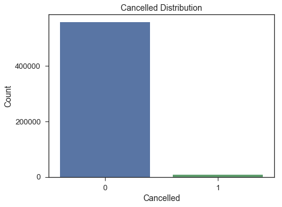

```python
#plt.style.use('fivethirtyeight')
#plt.style.use('ggplot')
fig, ax = plt.subplots(figsize=(6,5))
sns.countplot(train_set.Cancelled)
_ = plt.xticks(size=13)
_ = plt.yticks(size=13)
_ = plt.xlabel('Cancelled', size=14)
_ = plt.ylabel('Count', size=14)
_ = plt.title('Cancelled Distribution', size=14)
```

In the above graphic, `1` represents `Cancelled` flights and `0` `Non-cancelled`. As seen from the graphic, the Cancellation rate is fairly unbalanced.

__Flight Over Months__

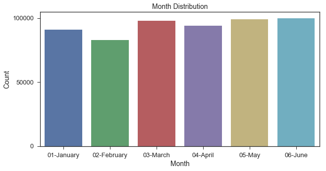

```python
fig, ax = plt.subplots(figsize=(9,5))
#plt.style.use('ggplot')
sns.countplot(train_set.MonthName.sort_values())
_ = plt.xticks(size=13)
_ = plt.yticks(size=13)
_ = plt.xlabel('Month', size=14)
_ = plt.ylabel('Count', size=14)
_ = plt.title('Month Distribution', size=14)
```

The flights are almost fairly distributed among the mounths. As we would expect, due to being the shortest month `February` has the least flight number.

__Flight Volumes by Companies__

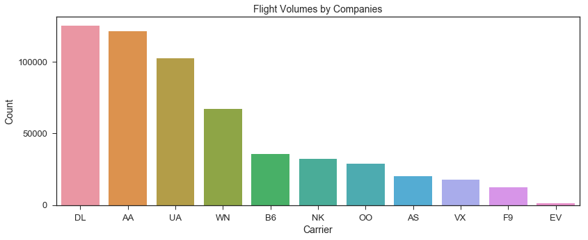

```python
fig, ax = plt.subplots(figsize=(12,5))
sns.countplot(train_set.Carrier, order=train_set.Carrier.value_counts().index)
_ = plt.xticks(size=13)
_ = plt.yticks(size=13)
_ = plt.xlabel('Carrier', size=14)
_ = plt.ylabel('Count', size=14)
_ = plt.title('Flight Volumes by Companies', size=14)
```

We have 11 Airline Companies woking between selected Origin-Destination route. Those companies and their flight numbers can be seen below :

Delta Air Lines Inc.: DL 125176

American Airlines Inc.: AA 121429

United Air Lines Inc.: UA 102586

Southwest Airlines Co.: WN 67331

JetBlue Airways: B6 35792

Spirit Air Lines: NK 32081

SkyWest Airlines Inc.: OO 29098

Alaska Airlines Inc.: AS 20285 Virgin America: VX 17984

Frontier Airlines Inc.: F9 12302

ExpressJet Airlines Inc.: EV 1520

As seen, Airline companies' flight numbers are not normally distributed. `Delta Airlines` has the most of the flights while `Express Airlines` has the minimum flight number. `Delta, American and United Airlines` compose almost 60% of all flights.

```python
pvt_scheduled_airline_date = train_set.pivot_table(index="MonthName",columns="Company",values="CRSElapsedTime", aggfunc=lambda x: x.count())
pvt_scheduled_airline_date
```

| Company MonthName | Alaska Airlines Inc.: AS | American Airlines Inc.: AA | Delta Air Lines Inc.: DL | ExpressJet Airlines Inc.: EV | Frontier Airlines Inc.: F9 | JetBlue Airways: B6 | SkyWest Airlines Inc.: OO | Southwest Airlines Co.: WN | Spirit Air Lines: NK | United Air Lines Inc.: UA | Virgin America: VX |
| --- | --- | --- | --- | --- | --- | --- | --- | --- | --- | --- | --- |
| 01-January | 3241.0 | 20094.0 | 19454.0 | 296.0 | 2171.0 | 5822.0 | 4659.0 | 11027.0 | 5259.0 | 16150.0 | 3024.0 |
| 02-February | 2883.0 | 18354.0 | 17853.0 | 227.0 | 1775.0 | 5406.0 | 4234.0 | 9855.0 | 4758.0 | 14986.0 | 2678.0 |
| 03-March | 3428.0 | 21008.0 | 21784.0 | 378.0 | 2099.0 | 6106.0 | 5015.0 | 11743.0 | 5350.0 | 17945.0 | 3054.0 |
| 04-April | 3454.0 | 19855.0 | 21149.0 | 238.0 | 2077.0 | 5994.0 | 5170.0 | 11426.0 | 5253.0 | 16690.0 | 2934.0 |
| 05-May | 3682.0 | 20911.0 | 22279.0 | 227.0 | 2085.0 | 6277.0 | 5041.0 | 11637.0 | 5766.0 | 18292.0 | 3113.0 |
| 06-June | 3597.0 | 21207.0 | 22657.0 | 154.0 | 2095.0 | 6187.0 | 4979.0 | 11643.0 | 5695.0 | 18523.0 | 3181.0 |

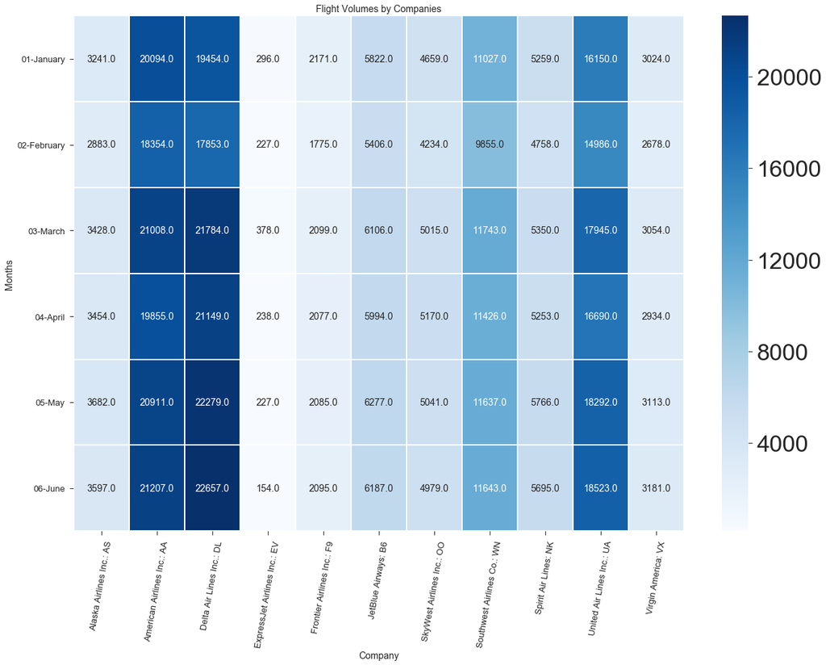

```python
fig = plt.figure(figsize=(18,14))
sns.heatmap(pvt_scheduled_airline_date, fmt='', annot=True, annot_kws={"size": 14}, cmap='Blues', linecolor="w", linewidths=1)
_ = plt.xticks(size=13, rotation=80)
_ = plt.yticks(size=13)
_ = plt.xlabel('Company', size=14)
_ = plt.ylabel('Months', size=14)
_ = plt.title('Flight Volumes by Companies', size=14)
```

Through heatmap and other graphics we can figure out the flight volume of each airline compnay. We can see in the previous plots and heatmap `Delta Airlines` is the __largest__ Airline company in volume of flights. `American Airlines` is the __second__ one and its flight volume is pretty close to Delta Airlines. And `United Air Lines` is the __third__ one for the same period. We can infer that those three companies have operated flights for almost all distances across the USA and they have larger fleet than other companies. On the other hand, `Express Airlines` is the __smallest__ company with the least volume.

**Operating Performance of the Companies**

```python
# Operation_rank_airlines shows cancellations and operated flights

operation_ranks_airlines = pd.DataFrame(train_set.groupby('Company').count()['CRSElapsedTime'])
operation_ranks_airlines['Scheduled_Flights'] = operation_ranks_airlines['CRSElapsedTime']
operation_ranks_airlines['Cancelled']=train_set.groupby('Company').sum()['Cancelled'].astype('int')
operation_ranks_airlines['Operated']=operation_ranks_airlines['CRSElapsedTime']-operation_ranks_airlines['Cancelled'].astype('int')
operation_ranks_airlines['Ratio_Operated']=operation_ranks_airlines['Operated']/operation_ranks_airlines['CRSElapsedTime']
operation_ranks_airlines['Ratio_Cancelled'] = 1- operation_ranks_airlines['Ratio_Operated']
operation_ranks_airlines.drop(operation_ranks_airlines.columns[[0]],axis=1,inplace=True)
operation_ranks_airlines
```

| Company | Scheduled_Flights | Cancelled | Operated | Ratio_Operated | Ratio_Cancelled |
| --- | --- | --- | --- | --- | --- |
| Alaska Airlines Inc.: AS | 20285 | 214 | 20071 | 0.989450 | 0.010550 |
| American Airlines Inc.: AA | 121429 | 1281 | 120148 | 0.989451 | 0.010549 |
| Delta Air Lines Inc.: DL | 125176 | 1101 | 124075 | 0.991204 | 0.008796 |
| ExpressJet Airlines Inc.: EV | 1520 | 82 | 1438 | 0.946053 | 0.053947 |
| Frontier Airlines Inc.: F9 | 12302 | 60 | 12242 | 0.995123 | 0.004877 |
| JetBlue Airways: B6 | 35792 | 927 | 34865 | 0.974100 | 0.025900 |
| SkyWest Airlines Inc.: OO | 29098 | 421 | 28677 | 0.985532 | 0.014468 |
| Southwest Airlines Co.: WN | 67331 | 1154 | 66177 | 0.982861 | 0.017139 |
| Spirit Air Lines: NK | 32081 | 1026 | 31055 | 0.968018 | 0.031982 |
| United Air Lines Inc.: UA | 102586 | 628 | 101958 | 0.993878 | 0.006122 |
| Virgin America: VX | 17984 | 405 | 17579 | 0.977480 | 0.022520 |

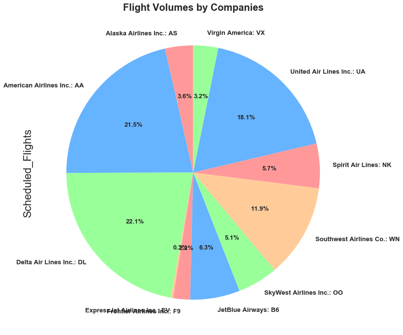

```python
_ = plt.figure()
fig = plt.figure(1, figsize=(10,7))
colors = ['#ff9999','#66b3ff','#99ff99','#ffcc99']
(operation_ranks_airlines['Scheduled_Flights']).plot.pie(figsize=(10,10), fontsize = 13, colors=colors, autopct='%1.1f%%', startangle=90)
_ = plt.title('Flight Volumes by Companies', weight='bold', size=20)
plt.tight_layout()
plt.show()
```

**Cancellation Volumes**

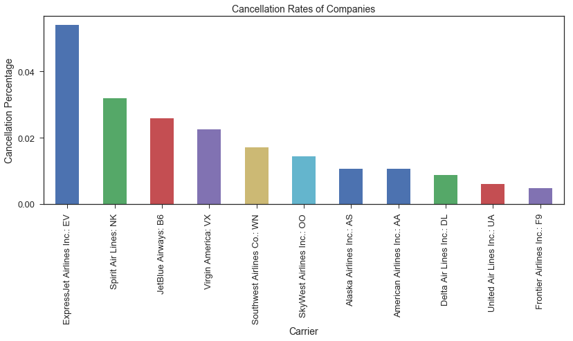

```python
_ = plt.figure()
fig, ax = plt.subplots(figsize=(12,5))
operation_ranks_airlines.Ratio_Cancelled.sort_values(ascending=False).plot(kind='bar')
_ = plt.xticks(size=13)
_ = plt.yticks(size=13)
_ = plt.xlabel('Carrier', size=14)
_ = plt.ylabel('Cancellation Percentage', size=14)
_ = plt.title('Cancellation Rates of Companies', size=14)
```

We can see that in terms of Cancellation Rates of the companies, `Express Airlines` has the highest cancellation rate of `5%`. Every one of 20 flights of Express Airline was cancelled. If you have a flight with Express Airlines you have a higher chance of cancellation. On the other hand `Frontier Airlines` has the **minimum Cancellation rate** and it has a good reputation for this term.

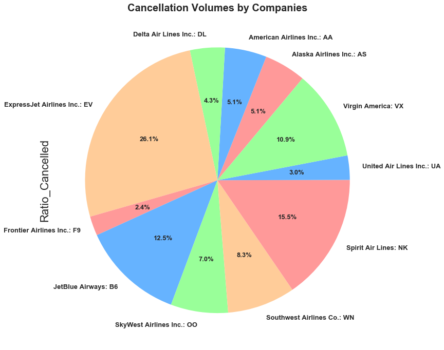

```python
_ = plt.figure()
fig = plt.figure(1, figsize=(10,7))
colors = ['#ff9999','#66b3ff','#99ff99','#ffcc99']
(operation_ranks_airlines['Ratio_Cancelled']/np.sum(operation_ranks_airlines['Ratio_Cancelled'])*100).plot.pie(figsize=(10,10), fontsize = 13, colors=colors, autopct='%1.1f%%', startangle=50)
_ = plt.title('Cancellation Volumes by Companies', weight='bold', size=20)
plt.tight_layout()
```

```python
plt.gca().axis("equal")

pie= (operation_ranks_airlines['Ratio_Cancelled']/np.sum(operation_ranks_airlines['Ratio_Cancelled'])*100).plot.pie(figsize=(10,10), fontsize = 13, colors=colors, labels=None, autopct='%1.0f%%', startangle=50)
pie = plt.pie(df, startangle=0, autopct='%1.0f%%', pctdistance=0.9, radius=1.2)
labels=df.index.unique()
plt.title('Pie Chart Demonstration', weight='bold', size=14)
plt.legend(pie[0],labels, bbox_to_anchor=(1,0.5), loc="center right", fontsize=10,
           bbox_transform=plt.gcf().transFigure)
plt.subplots_adjust(left=0.0, bottom=0.1, right=0.85)

plt.show()
plt.clf()
plt.close()
```

**Cancellations over Month**

```python
for_plt = pd.pivot_table(train_set, index='MonthName', columns='Company', values='Cancelled', aggfunc='sum')
for_plt
```

| Company MonthName | Alaska Airlines Inc.: AS | American Airlines Inc.: AA | Delta Air Lines Inc.: DL | ExpressJet Airlines Inc.: EV | Frontier Airlines Inc.: F9 | JetBlue Airways: B6 | SkyWest Airlines Inc.: OO | Southwest Airlines Co.: WN | Spirit Air Lines: NK | United Air Lines Inc.: UA | Virgin America: VX |
| --- | --- | --- | --- | --- | --- | --- | --- | --- | --- | --- | --- |
| 01-January | 38 | 253 | 175 | 15 | 33 | 112 | 107 | 270 | 169 | 74 | 68 |
| 02-February | 73 | 183 | 111 | 13 | 6 | 230 | 121 | 164 | 60 | 175 | 101 |
| 03-March | 22 | 270 | 127 | 26 | 15 | 234 | 62 | 291 | 97 | 253 | 87 |
| 04-April | 24 | 168 | 639 | 7 | 1 | 70 | 73 | 140 | 89 | 14 | 56 |
| 05-May | 39 | 112 | 18 | 8 | 4 | 136 | 20 | 116 | 359 | 25 | 63 |
| 06-June | 18 | 295 | 31 | 13 | 1 | 145 | 38 | 173 | 252 | 87 | 30 |

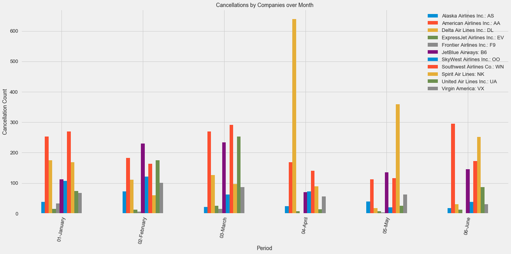

```python
_ = plt.figure()
for_plt.plot(kind= 'bar', figsize=(20,9))
_ = plt.xticks(size=13, rotation=80)
_ = plt.yticks(size=13)
_ = plt.xlabel('Period', size=14)
_ = plt.ylabel('Cancellation Count', size=14)
_ = plt.title('Cancellations by Companies over Month', size=14)
_ = plt.legend(loc='best', fontsize=13)
plt.show()
```

**Cancellations over Day of Week**

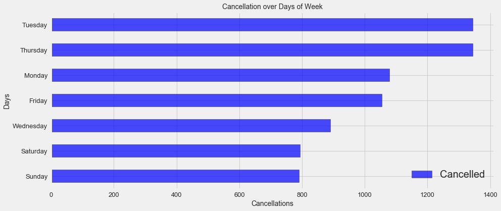

```python
#day_of_cancellation = pd.DataFrame(merged[merged.Cancelled==1].groupby('DayOfWeekName')['Cancelled'].sum())
_ = plt.figure()
#fig = plt.subplots(1,2)
cancellation_over_days = pd.DataFrame(train_set.groupby('DayOfWeekName')['Cancelled'].sum())
cancellation_over_days['Cancelled'].sort_values(ascending=True).plot(kind= 'barh', figsize=(14,6), color='Blue', legend=True, alpha=0.7, edgecolor='black')
_ = plt.xticks(size=13)
_ = plt.yticks(size=13)
_ = plt.ylabel('Days', size=14)
_ = plt.title('Cancellation over Days of Week', size=14)
_ = plt.xlabel('Cancellations', size=14)
```

When we check days in terms of cancelled flight numbers, `Tuesday` has the most cancelled flights and `Thursday` has the second highest cancelled flights. If you are planning to have a flight you may have a higher chance of cancellation on those days. We can group the flights as weekday flight or not. In this context, we will create a new column which holds the flights occur in weekday or weekend.

```python
train_set['PartOfWeek'] = train_set['DayOfWeek'].map(lambda x : 'weekday' if x <= 5 else 'weekend')
```

**Cancellations over Day of Month**

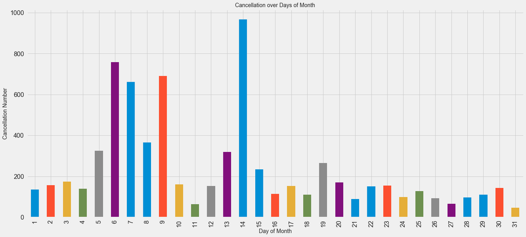

```python
for_plot = train_set.groupby(['DayofMonth'])['Cancelled'].sum()
for_plot.plot(kind='bar', figsize=(20,9))
_ = plt.xticks(size=16)
_ = plt.yticks(size=16)
_ = plt.ylabel('Cancellation Number', size=14)
_ = plt.title('Cancellation over Days of Month', size=14)
_ = plt.xlabel('Day of Month', size=14)
```

Cancellations occured on **14th day months** mostly. Generally speaking more than half of the all cancellations has occured **in the first half of the month rather than second half.** In this context, we will create a new categorical feature **(named PartOfMonth)** showing the flighst belonging to either first part of the month or second.

```python
train_set['PartOfMonth'] = train_set['DayofMonth'].map(lambda x: 'first' if x < 16 else 'second')
```

**Cancellations over Hour**

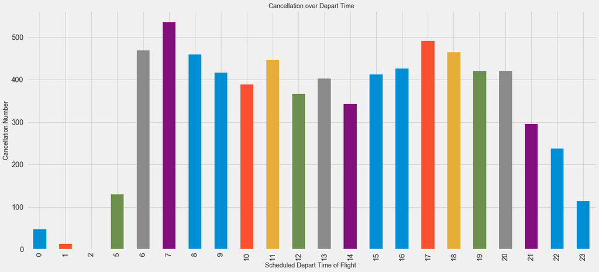

```python
#merged['DepartHour'] = merged.FlightDateTime_Dest.dt.hour
for_plot = train_set.groupby(['Flight_Hour'])['Cancelled'].sum()
for_plot.plot(kind='bar', figsize=(20,9))
_ = plt.xticks(size=16)
_ = plt.yticks(size=16)
_ = plt.ylabel('Cancellation Number', size=14)
_ = plt.title('Cancellation over Depart Time', size=14)
_ = plt.xlabel('Scheduled Depart Time of Flight ', size=14)
```

```python
train_set['PartOfDay'] = train_set['Flight_Hour'].map(lambda x: 'most' if ((x >=6) and (x < 21)) else 'few' if ((x > 1) and (x < 6))  else 'less')
```

```python
train_set['PartOfDay'].value_counts()
```

```
most    508282
less     46437
few      10865
Name: PartOfDay, dtype: int64
```

**Distance Aspect**

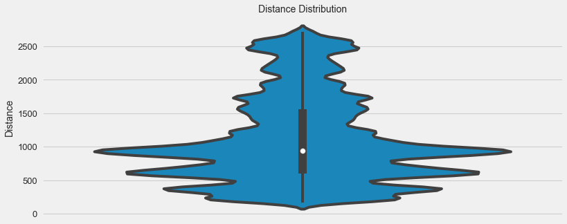

```python
fig, ax = plt.subplots(figsize=(12,5))
ax = sns.violinplot(y='Distance',data=train_set)
_ = plt.xticks(size=13)
_ = plt.yticks(size=13)
_ = plt.ylabel('Distance', size=14)
_ = plt.title('Distance Distribution', size=14)
```

`Median` flight distance is pretty close to **1000 mile**. And distance has a highly **right skewed** distribution. We need to transform this varible before modeling, if we decide to keep it in our model.

**Scheduled Elapsed Time**

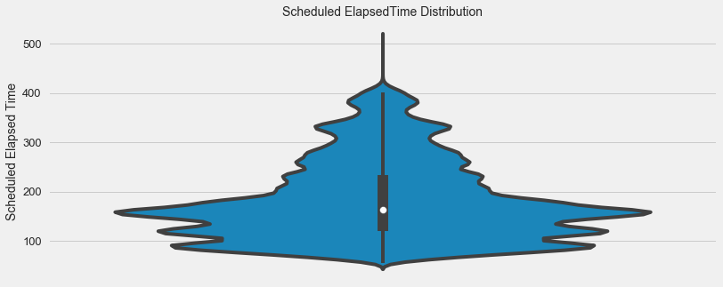

```python
fig, ax = plt.subplots(figsize=(12,5))
sns.violinplot(y='CRSElapsedTime', data=train_set)
_ = plt.xticks(size=13)
_ = plt.yticks(size=13)
_ = plt.ylabel('Scheduled Elapsed Time', size=14)
_ = plt.title('Scheduled ElapsedTime Distribution', size=14)
```

The **median Scheduled Elasped Time is 163 minustes** and as we can see Scheduled Elasped Time has also highly right skewed distribution. Before building a model we have to transform it as well

**Average Speed of Airline Companies**

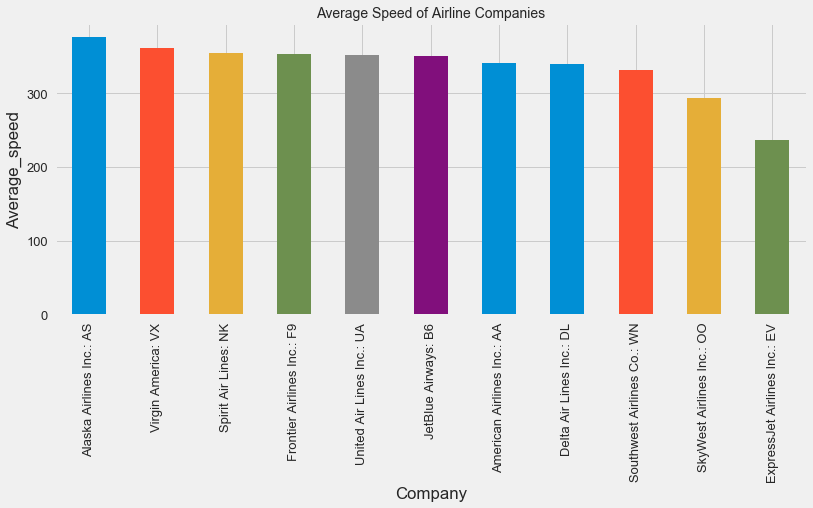

```python
fig, ax = plt.subplots(figsize=(12,5))
_ = plt.xticks(size=13)
_ = plt.yticks(size=13)
_ = plt.ylabel('Average_speed')
_ = plt.title ('Average Speed of Airline Companies', size=14)
train_set['Average_Speed'] = (train_set['Distance']/(train_set['CRSElapsedTime']/60))
train_set.groupby(['Company'])['Average_Speed'].mean().sort_values(ascending=False).plot(kind='bar')
```

The fastest Airline Company is Alaska Airlines with 375 miles/hour avarage speed. ExpressJest Airline is the slowest company.

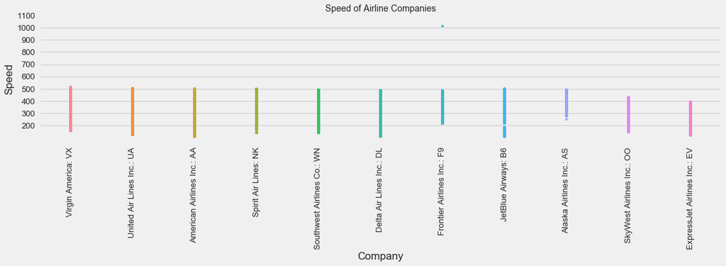

```python
plt.subplots(figsize=[16,6])
sns.stripplot(x='Company',y='Average_Speed',data=train_set, size=4)
_ = plt.ylabel('Speed')
_ = plt.title('Speed of Airline Companies', size=14)
_ = plt.xticks(size=13, rotation=90)
_ = plt.yticks([200,300, 400,500, 600,700, 800,900, 1000, 1100], size=13)
plt.tight_layout()
plt.show()
```

`Frontier Airline` has an flight speed with more than **1000 miles/hour** and it is impossible for an Airliner. We will consider it as an **outlier** and drop it.

```python
temp = train_set['Distance']/(train_set['CRSElapsedTime']/60)>680 ## 680 knots is avarage maximum speed of Airliners.
#train_set[train_set['Carrier']=='F9'][temp]
train_set[temp]
```

|  | Quarter | Month | DayofMonth | DayOfWeek | Carrier | Origin | Dest | DepDelayMinutes | TaxiOut | Cancelled | CRSElapsedTime | Distance | Company | FlightDateTime_Origin | FlightDateTime_Dest | Flight_Hour | MonthName | DayOfWeekName | PartOfWeek | PartOfMonth | PartOfDay | Average_Speed |
| --- | --- | --- | --- | --- | --- | --- | --- | --- | --- | --- | --- | --- | --- | --- | --- | --- | --- | --- | --- | --- | --- | --- |
| 369532 | 2 | 6 | 21 | 3 | F9 | SFO | MCO | 202.0 | 15.0 | 0 | 145.0 | 2446.0 | Frontier Airlines Inc.: F9 | 2017-06-21 22:59:00 | 2017-06-22 02:24:00 | 22 | 06-June | Wednesday | weekday | second | less | 1012.137931 |

```python
## There is only one outlier in terms of speed in our dataset an we will drop it.
train_set.drop([369532], inplace=True)
```

**Cancellations over Origin Airport**

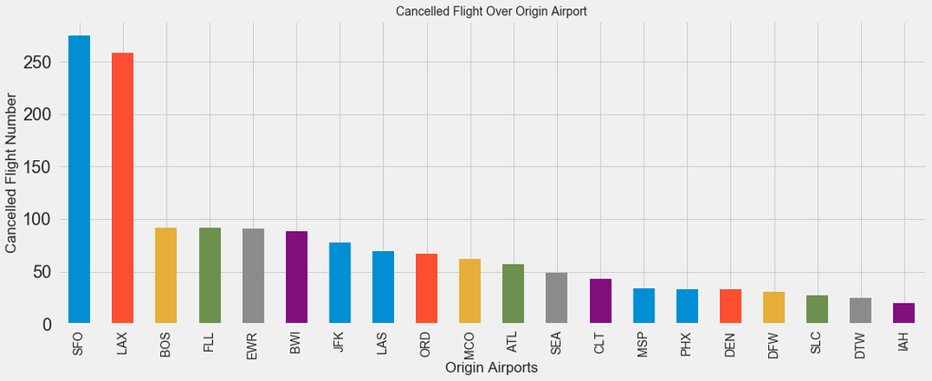

```python
plt.subplots(figsize=[16,6])
for_plt = pd.pivot_table(train_set, index='Dest', columns='Origin', values='Cancelled', aggfunc='sum').sort_index(ascending=True)
sorted(for_plt)
for_plt.max().sort_values(ascending=False).plot(kind='bar')
_ = plt.ylabel('Cancelled Flight Number')
_ = plt.xlabel('Origin Airports')
_ = plt.title('Cancelled Flight Over Origin Airport', size=14)
_ = plt.xticks(size=14, rotation=90)
```

In case the reader is not familiar with these airport codes, following is the mapping between codes and names:

ATL - Hartsfield Jackson Atlanta International

BOS - General Edward Lawrence Logan International Boston

BWI - Baltimore/Washington International Thurgood Marshall Baltimore

CLT - Charlotte Douglas International Charlotte

DEN - Denver International Denver

DFW - Dallas Fort Worth International Dallas-Fort Worth

DTW - Detroit Metropolitan Wayne County Detroit

EWR - Newark Liberty International Newark

IAH - George Bush Intercontinental Houston Houston

JFK - John F Kennedy International New York

LAS - McCarran International Las Vegas

LAX - Los Angeles International Los Angeles

MCO - Orlando International Orlando

MSP - Minneapolis-St Paul International/Wold-Chamberlain Minneapolis

ORD - Chicago O’Hare International

PHX - Phoenix Sky Harbor International Phoenix

SEA - Seattle Tacoma International Seattle

SFO - San Francisco International San Francisco

SLC - Salt Lake City International Salt Lake City

# FEATURE ENGINEERING

```python
train_set.head(3)
```

|  | Quarter | Month | DayofMonth | DayOfWeek | Carrier | Origin | Dest | DepDelayMinutes | TaxiOut | Cancelled | CRSElapsedTime | Distance | Company | FlightDateTime_Origin | FlightDateTime_Dest | Flight_Hour | MonthName | DayOfWeekName | PartOfWeek | PartOfMonth | PartOfDay | Average_Speed |
| --- | --- | --- | --- | --- | --- | --- | --- | --- | --- | --- | --- | --- | --- | --- | --- | --- | --- | --- | --- | --- | --- | --- |
| 694436 | 1 | 3 | 30 | 4 | VX | SFO | LAX | 0.0 | 41.0 | 0 | 85.0 | 337.0 | Virgin America: VX | 2017-03-30 08:00:00 | 2017-03-30 09:25:00 | 8 | 03-March | Thursday | weekday | second | most | 237.882353 |
| 524560 | 2 | 4 | 2 | 7 | UA | DTW | DEN | 0.0 | 11.0 | 0 | 198.0 | 1123.0 | United Air Lines Inc.: UA | 2017-04-02 15:35:00 | 2017-04-02 16:53:00 | 15 | 04-April | Sunday | weekend | first | most | 340.303030 |
| 20719 | 1 | 1 | 26 | 4 | AA | LAX | ORD | 0.0 | 24.0 | 0 | 253.0 | 1744.0 | American Airlines Inc.: AA | 2017-01-26 23:50:00 | 2017-01-27 06:03:00 | 23 | 01-January | Thursday | weekday | second | less | 413.596838 |

**Looking for Relationships**

Bivariate Analysis

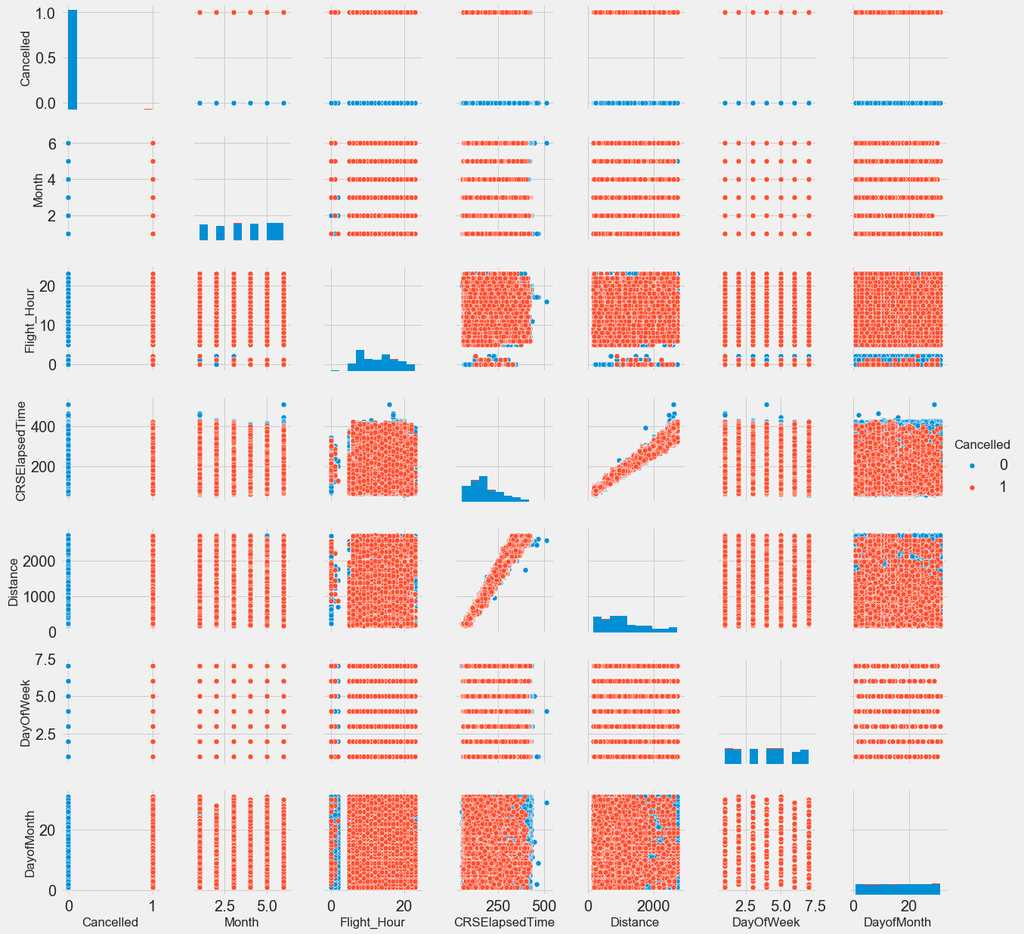

```python
#sns.set_style('darkgrid')
plt.rcParams['figure.figsize']=18,10
sns.pairplot(train_set[['Cancelled','Month','Flight_Hour','CRSElapsedTime','Distance','DayOfWeek', 'DayofMonth']],hue='Cancelled')
ax.spines['right'].set_visible(False)
ax.spines['top'].set_visible(False)
```

As we can visually understand from the pairplots there seems to be a **strong positive correlation** between **Scheduled Elasped Time** and **Distance**. Let's get look at it closer through the larger scatter plot below.

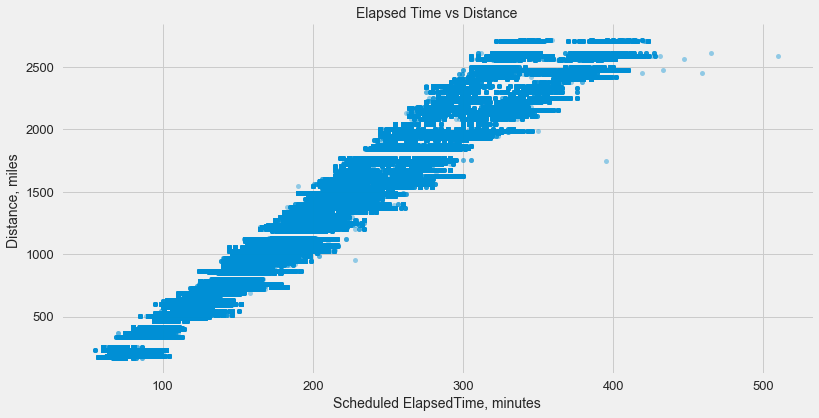

```python
fig, ax  =  plt.subplots(figsize=(12,6))
ax.plot(train_set.CRSElapsedTime, train_set.Distance, marker='o', linestyle='', ms=5, alpha=0.4)
plt.xlabel("CRSElapsedTime, mins")
plt.ylabel("Distance, miles")
_ = plt.xticks(size=13)
_ = plt.yticks(size=13)
_ = plt.xlabel('Scheduled ElapsedTime, minutes', size=14)
_ = plt.ylabel('Distance, miles ', size=14)
_ = plt.title('Elapsed Time vs Distance', size=14)
ax.spines['right'].set_visible(False)
ax.spines['top'].set_visible(False)
```

Visually, we can observe a strong positive correlation with few outliers. For some distances there are many CRSElapsedTime. This could be due to time-zone difference, or because of changes in reservation system for same distance flights. Here we will perform a hypothesis test to check the correlation. In this context we will start with calculating a **Pearson correlation coefficient**. But as it is known for this calculation both CRSElapsedTime and Distance have to be normally distributed. Then, let us check their distribution first. If the correlation is proved then we are supposed to include only one of both varibles into our model.

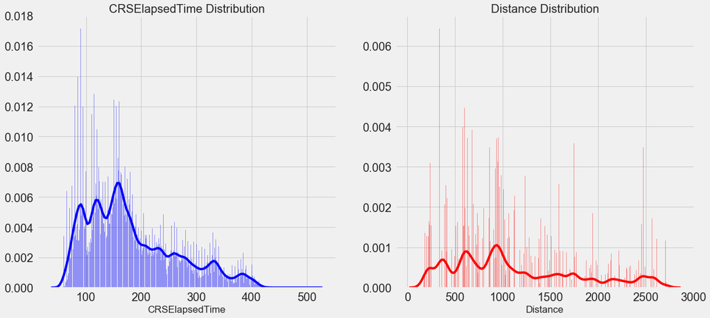

```python
fig, (ax1, ax2) = plt.subplots(1, 2, figsize=(18,8))
sns.distplot(train_set.CRSElapsedTime, 500, ax=ax1,color='b')
ax1.set_title("CRSElapsedTime Distribution")
sns.distplot(train_set.Distance, 500, ax=ax2, color='r')
ax2.set_title("Distance Distribution")
plt.show()
```

From the figures both Scheduled Elapsed Time and Distance don't seem to be normal distributions. So we are supposed to test the p-values

```python
from scipy import stats
stats.normaltest(train_set.CRSElapsedTime)
```

```
NormaltestResult(statistic=47416.983051577859, pvalue=0.0)
```

```python
stats.normaltest(train_set.Distance)
```

```
NormaltestResult(statistic=47420.531205496394, pvalue=0.0)
```

For both pvalue are 0 and less than 0.05 so we `can rejct the null hypothesis`. It suggests that the the distribution is not normal. **We cannot use Pearson's correlation coefficient** in this case, but a non-parametric test such as `Spearman's test`. It is time to calculate the Spearman's correlation coefficient to check the correlation between CRSElepasedTime and Distance.

```python
stats.spearmanr(train_set.CRSElapsedTime, train_set.Distance)
```

```
SpearmanrResult(correlation=0.98326179624589338, pvalue=0.0)
```

According to the test result we can reject the null hypothesis suggesting there is no correlation between varaibales, and accept the alternate hypothesis suggesting there is pretty `strong positive correlation` (98%) between two variables. We can also confirm this correlation through heatmap.

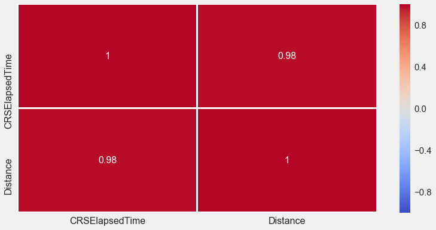

```python
fig = plt.subplots(figsize=(12,6))
sns.set(font_scale=1.5)

corr = train_set[['CRSElapsedTime','Distance']].corr()
sns.heatmap(corr, annot=True, cmap='coolwarm', annot_kws={"size": 16}, vmin=-1, vmax=1, lw=2)
_ = plt.xticks(size=16)
_ = plt.yticks(size=16)
```

After double check, now we can drop one of both varibles from our data set.

Now it is time to find which variable is supposed to be dropped from our model. For this aim, now let's use `t-test` to check whether Cancelled varibale has an association with either CRSElapsedTime or Distance

First, we will compare the mean value of the CRSElapsedTime variable between Cancelled and Non-canceled flights. We will use `Welch's T-test` instead of T-test, because as we detected earlier there is a quite **imbalance between Cancelled and Non-cancelled**.

As it is known T-test/Welch's T test requires/assumes normally distributed data. We have a problem here because as we observed earlier, the CRSElapsedTime and Distance variables are not distributed normally. In this context, first we are supossed to transform these variables into normalization. Our preference to do so is **Box-Cox transformation**.

You can see the original data distribution graphic to remember on the left and transformed data on the right graphic.

```
Text(0.5,1,'CRSElapsedTime Distribution (After Transform)')
```

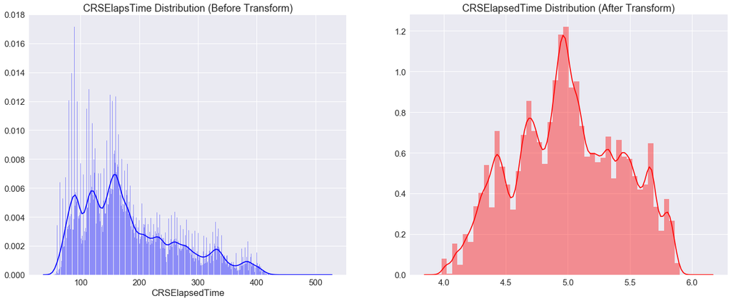

```python
_ = plt.figure()
fig, (ax1, ax2) = plt.subplots(1, 2, figsize=(20,8))

ax1 = sns.distplot(train_set.CRSElapsedTime, 500, ax=ax1,color='b')
ax1.set_title('CRSElapsTime Distribution (Before Transform)')

ax2 = sns.distplot(stats.boxcox(train_set['CRSElapsedTime'])[0], ax=ax2, color='r')
ax2.set_title('CRSElapsedTime Distribution (After Transform)')
```

We will do the same thing for Distance variable.

```
Text(0.5,1,'Distance Distribution (After Transform)')
```

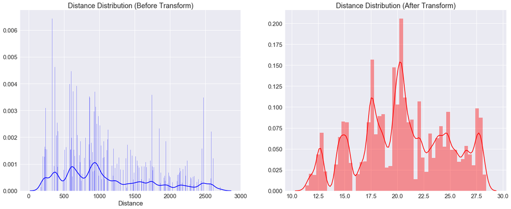

```python
fig, (ax1, ax2) = plt.subplots(1, 2, figsize=(20,8))

ax1 = sns.distplot(train_set.Distance, 500, ax=ax1,color='b')
ax1.set_title('Distance Distribution (Before Transform)')

ax2 = sns.distplot(stats.boxcox(train_set['Distance'])[0], ax=ax2, color='r')
ax2.set_title('Distance Distribution (After Transform)')
```

Although both varibales do not seem perfectly normally distributed, but they look much better after Box-Cox transformation. Now, we can perform T-test with those transformed variables.

The hypothesis of T-test for those variables:

**H0 : The means between Cancelled and Non-cancelled are the same**

**H1 : The means between Cancelled and Non-cancelled are NOT the same**

**Alpha : 0.05 ==> C.I. :0.95**

```python
t, p = stats.ttest_ind(stats.boxcox(train_set[train_set['Cancelled'] == 0].CRSElapsedTime)[0],
                       stats.boxcox(train_set[train_set['Cancelled'] == 1].CRSElapsedTime)[0],
                       equal_var=False)

print('CRSElapsedTime for Cancelled vs. Non-cancelled Flights')
print('------------------------------------------------------')
print('t-statistic: %s' % t)
print('p-value    : %s' % p)
```

```
CRSElapsedTime for Cancelled vs. Non-cancelled Flights
------------------------------------------------------
t-statistic: 963.161312272
p-value    : 0.0
```

T-test for CRSElapsedTime: The T-statistic is 963.1 and the p-value is 0. This **p-value is strictly below our alpha of 0.05** and therefore `we can safely reject the null hypothesis`. There is statistically significant evidence that the mean CRSElapsedTime values for Cancelled and Non-canceled flights are not the same.

```python
t, p = stats.ttest_ind(stats.boxcox(train_set[train_set['Cancelled'] == 0].Distance)[0],
                       stats.boxcox(train_set[train_set['Cancelled'] == 1].Distance)[0],
                       equal_var=False)

print('Distance for Cancelled vs. Non-cancelled Flights')
print('------------------------------------------------------')
print('t-statistic: %s' % t)
print('p-value    : %s' % p)
```

```
Distance for Cancelled vs. Non-cancelled Flights
------------------------------------------------------
t-statistic: 401.149674493
p-value    : 0.0
```

T-test for Distance: The T-statistic is 401 and the p-value is 0. This **p-value also is far below our alpha of 0.05** and therefore `we can safely reject the null hypothesis`, as well. There is statistically significant evidence that the mean Distance values for Cancelled and Non-canceled flights are not the same.

We have already prove that **Distance and CRSElapsedTime have a strong positive correlataion** with each other and decide to remove one of both from our model. We see that t-statistic of CRSElapsedTime is greater than t-statistic of Distance so we decided to include CRSElapseTime to our model rather than Distance

```python
train_set.drop(['Distance'], axis=1, inplace=True)
```

```python
dropped_columns.extend(['Distance'])
```

```python
## Correlation Matrix
corr_matrix = train_set.corr()
corr_matrix['Cancelled'].sort_values(ascending=False)
```

```
Cancelled          1.000000
DepDelayMinutes    0.197581
TaxiOut            0.112548
Flight_Hour        0.008963
DayOfWeek         -0.010062
CRSElapsedTime    -0.014297
Month             -0.016125
Quarter           -0.016406
Average_Speed     -0.024029
DayofMonth        -0.040031
Name: Cancelled, dtype: float64
```

**Dropping Unnecessary Columns**

We will drop Quater, Month, DayofMonth, DayOfWeek, Flight_Hour columns. Most of them already converted into categorical values and we will use them in our model.

```python
train_set.head()
```

|  | Quarter | Month | DayofMonth | DayOfWeek | Carrier | Origin | Dest | DepDelayMinutes | TaxiOut | Cancelled | CRSElapsedTime | Company | FlightDateTime_Origin | FlightDateTime_Dest | Flight_Hour | MonthName | DayOfWeekName | PartOfWeek | PartOfMonth | PartOfDay | Average_Speed |
| --- | --- | --- | --- | --- | --- | --- | --- | --- | --- | --- | --- | --- | --- | --- | --- | --- | --- | --- | --- | --- | --- |
| 694436 | 1 | 3 | 30 | 4 | VX | SFO | LAX | 0.0 | 41.0 | 0 | 85.0 | Virgin America: VX | 2017-03-30 08:00:00 | 2017-03-30 09:25:00 | 8 | 03-March | Thursday | weekday | second | most | 237.882353 |
| 524560 | 2 | 4 | 2 | 7 | UA | DTW | DEN | 0.0 | 11.0 | 0 | 198.0 | United Air Lines Inc.: UA | 2017-04-02 15:35:00 | 2017-04-02 16:53:00 | 15 | 04-April | Sunday | weekend | first | most | 340.303030 |
| 20719 | 1 | 1 | 26 | 4 | AA | LAX | ORD | 0.0 | 24.0 | 0 | 253.0 | American Airlines Inc.: AA | 2017-01-26 23:50:00 | 2017-01-27 06:03:00 | 23 | 01-January | Thursday | weekday | second | less | 413.596838 |
| 146361 | 2 | 6 | 4 | 7 | AA | DFW | SFO | 28.0 | 24.0 | 0 | 221.0 | American Airlines Inc.: AA | 2017-06-04 22:05:00 | 2017-06-04 23:46:00 | 22 | 06-June | Sunday | weekend | first | less | 397.466063 |
| 409876 | 2 | 6 | 26 | 1 | NK | DFW | ORD | 3.0 | 20.0 | 0 | 151.0 | Spirit Air Lines: NK | 2017-06-26 16:49:00 | 2017-06-26 19:20:00 | 16 | 06-June | Monday | weekday | second | most | 318.675497 |

```python
train_set.drop(['Quarter', 'Month', 'DayofMonth', 'DayOfWeek', 'Flight_Hour', 'Company', 'FlightDateTime_Origin', 'FlightDateTime_Dest', 'MonthName', 'DayOfWeekName'], axis=1, inplace=True)
```

```python
## Saving those columns to drop for test_set
dropped_columns.extend(['Quarter', 'Month', 'DayofMonth', 'DayOfWeek', 'Flight_Hour', 'Company', 'FlightDateTime_Origin', 'FlightDateTime_Dest', 'MonthName', 'DayOfWeekName'])
```

**Transforming/ Scaling & Encoding**

```python
from sklearn.preprocessing import StandardScaler, LabelBinarizer

train_set_transf = train_set.copy()

# Assigning Target Column for Train Set
train_set_target = train_set['Cancelled']

#Droping Target Column
train_set.drop(['Cancelled'], axis=1, inplace=True)

# Select the numeric columns
numeric_subset = train_set.select_dtypes('number')
```

```python
# Select the categorical columns
categorical_subset = train_set[['Carrier', 'Origin', 'Dest', 'PartOfMonth', 'PartOfWeek', 'PartOfDay']]

numeric_subset.reset_index(drop=True).head()
#train_set[numeric_subset] = train_set.apply(lambda x : StandardScaler().fit_transform(x))
```

|  | DepDelayMinutes | TaxiOut | CRSElapsedTime | Average_Speed |
| --- | --- | --- | --- | --- |
| 0 | 0.0 | 41.0 | 85.0 | 237.882353 |
| 1 | 0.0 | 11.0 | 198.0 | 340.303030 |
| 2 | 0.0 | 24.0 | 253.0 | 413.596838 |
| 3 | 28.0 | 24.0 | 221.0 | 397.466063 |
| 4 | 3.0 | 20.0 | 151.0 | 318.675497 |

```python
categorical_subset.reset_index(drop=True).head()
```

|  | Carrier | Origin | Dest | PartOfMonth | PartOfWeek | PartOfDay |
| --- | --- | --- | --- | --- | --- | --- |
| 0 | VX | SFO | LAX | second | weekday | most |
| 1 | UA | DTW | DEN | first | weekend | most |
| 2 | AA | LAX | ORD | second | weekday | less |
| 3 | AA | DFW | SFO | first | weekend | less |
| 4 | NK | DFW | ORD | second | weekday | most |

```python
#DataFrameMapper
from sklearn_pandas import DataFrameMapper

mapper = DataFrameMapper([(list(numeric_subset.columns), StandardScaler()),
                          ('Carrier', LabelBinarizer()),
                          ('Origin', LabelBinarizer()),
                          ('Dest', LabelBinarizer()),
                          ('PartOfMonth', LabelBinarizer()),
                          ('PartOfWeek', LabelBinarizer()),
                          ('PartOfDay', LabelBinarizer()),], df_out=True)

output_df = mapper.fit_transform(train_set)
```

```python
output_df = pd.DataFrame(output_df)
output_df.head()
```

|  | DepDelayMinutes_TaxiOut_CRSElapsedTime_Average_Speed_0 | DepDelayMinutes_TaxiOut_CRSElapsedTime_Average_Speed_1 | DepDelayMinutes_TaxiOut_CRSElapsedTime_Average_Speed_2 | DepDelayMinutes_TaxiOut_CRSElapsedTime_Average_Speed_3 | Carrier_AA | Carrier_AS | Carrier_B6 | Carrier_DL | Carrier_EV | Carrier_F9 | Carrier_NK | Carrier_OO | Carrier_UA | Carrier_VX | Carrier_WN | Origin_ATL | Origin_BOS | Origin_BWI | Origin_CLT | Origin_DEN | Origin_DFW | Origin_DTW | Origin_EWR | Origin_FLL | Origin_IAH | Origin_JFK | Origin_LAS | Origin_LAX | Origin_MCO | … |
| --- | --- | --- | --- | --- | --- | --- | --- | --- | --- | --- | --- | --- | --- | --- | --- | --- | --- | --- | --- | --- | --- | --- | --- | --- | --- | --- | --- | --- | --- | --- |
| 694436 | -0.369442 | 2.282569 | -1.189610 | -1.426383 | 0.0 | 0.0 | 0.0 | 0.0 | 0.0 | 0.0 | 0.0 | 0.0 | 0.0 | 1.0 | 0.0 | 0.0 | 0.0 | 0.0 | 0.0 | 0.0 | 0.0 | 0.0 | 0.0 | 0.0 | 0.0 | 0.0 | 0.0 | 0.0 | 0.0 | … |
| 524560 | -0.369442 | -0.775298 | 0.190132 | -0.030760 | 0.0 | 0.0 | 0.0 | 0.0 | 0.0 | 0.0 | 0.0 | 0.0 | 1.0 | 0.0 | 0.0 | 0.0 | 0.0 | 0.0 | 0.0 | 0.0 | 0.0 | 1.0 | 0.0 | 0.0 | 0.0 | 0.0 | 0.0 | 0.0 | 0.0 | … |
| 20719 | -0.369442 | 0.549777 | 0.861687 | 0.967969 | 1.0 | 0.0 | 0.0 | 0.0 | 0.0 | 0.0 | 0.0 | 0.0 | 0.0 | 0.0 | 0.0 | 0.0 | 0.0 | 0.0 | 0.0 | 0.0 | 0.0 | 0.0 | 0.0 | 0.0 | 0.0 | 0.0 | 0.0 | 1.0 | 0.0 | … |
| 146361 | 0.252863 | 0.549777 | 0.470964 | 0.748165 | 1.0 | 0.0 | 0.0 | 0.0 | 0.0 | 0.0 | 0.0 | 0.0 | 0.0 | 0.0 | 0.0 | 0.0 | 0.0 | 0.0 | 0.0 | 0.0 | 1.0 | 0.0 | 0.0 | 0.0 | 0.0 | 0.0 | 0.0 | 0.0 | 0.0 | … |
| 409876 | -0.302767 | 0.142062 | -0.383743 | -0.325465 | 0.0 | 0.0 | 0.0 | 0.0 | 0.0 | 0.0 | 1.0 | 0.0 | 0.0 | 0.0 | 0.0 | 0.0 | 0.0 | 0.0 | 0.0 | 0.0 | 1.0 | 0.0 | 0.0 | 0.0 | 0.0 | 0.0 | 0.0 | 0.0 | 0.0 | … |

```python
#train_set_transformed = pd.DataFrame(output_df)
column_name = ['DepDelayMinutes','TaxiOut','CRSElapsedTime','Average_Speed','Carrier_AA',\
               'Carrier_AS','Carrier_B6','Carrier_DL','Carrier_EV','Carrier_F9','Carrier_NK','Carrier_OO','Carrier_UA','Carrier_VX','Carrier_WN','Origin_ATL',\
               'Origin_BOS','Origin_BWI','Origin_CLT','Origin_DEN','Origin_DFW','Origin_DTW','Origin_EWR','Origin_FLL','Origin_IAH','Origin_JFK','Origin_LAS',\
               'Origin_LAX','Origin_MCO','Origin_MSP','Origin_ORD','Origin_PHX','Origin_SEA','Origin_SFO','Origin_SLC','Dest_ATL','Dest_BOS','Dest_BWI','Dest_CLT',\
               'Dest_DEN','Dest_DFW','Dest_DTW','Dest_EWR','Dest_FLL','Dest_IAH','Dest_JFK','Dest_LAS','Dest_LAX','Dest_MCO','Dest_MSP','Dest_ORD','Dest_PHX','Dest_SEA',\
               'Dest_SFO','Dest_SLC', 'PartOfMonth', 'PartOfWeek', 'PartOfDay_few', 'PartOfDay_less', 'PartOfDay_most']
```

```python
train_set_transformed= output_df
```

```python
train_set_transformed.columns=column_name
```

```python
train_set_transformed = train_set_transformed.reset_index(drop=True)
train_set_transformed.head()
```

|  | DepDelayMinutes | TaxiOut | CRSElapsedTime | Average_Speed | Carrier_AA | Carrier_AS | Carrier_B6 | Carrier_DL | Carrier_EV | Carrier_F9 | Carrier_NK | Carrier_OO | Carrier_UA | Carrier_VX | Carrier_WN | Origin_ATL | Origin_BOS | Origin_BWI | Origin_CLT | Origin_DEN | Origin_DFW | Origin_DTW | Origin_EWR | Origin_FLL | Origin_IAH | Origin_JFK | Origin_LAS | Origin_LAX | Origin_MCO | … |
| --- | --- | --- | --- | --- | --- | --- | --- | --- | --- | --- | --- | --- | --- | --- | --- | --- | --- | --- | --- | --- | --- | --- | --- | --- | --- | --- | --- | --- | --- | --- |
| 0 | -0.369442 | 2.282569 | -1.189610 | -1.426383 | 0.0 | 0.0 | 0.0 | 0.0 | 0.0 | 0.0 | 0.0 | 0.0 | 0.0 | 1.0 | 0.0 | 0.0 | 0.0 | 0.0 | 0.0 | 0.0 | 0.0 | 0.0 | 0.0 | 0.0 | 0.0 | 0.0 | 0.0 | 0.0 | 0.0 | … |
| 1 | -0.369442 | -0.775298 | 0.190132 | -0.030760 | 0.0 | 0.0 | 0.0 | 0.0 | 0.0 | 0.0 | 0.0 | 0.0 | 1.0 | 0.0 | 0.0 | 0.0 | 0.0 | 0.0 | 0.0 | 0.0 | 0.0 | 1.0 | 0.0 | 0.0 | 0.0 | 0.0 | 0.0 | 0.0 | 0.0 | … |
| 2 | -0.369442 | 0.549777 | 0.861687 | 0.967969 | 1.0 | 0.0 | 0.0 | 0.0 | 0.0 | 0.0 | 0.0 | 0.0 | 0.0 | 0.0 | 0.0 | 0.0 | 0.0 | 0.0 | 0.0 | 0.0 | 0.0 | 0.0 | 0.0 | 0.0 | 0.0 | 0.0 | 0.0 | 1.0 | 0.0 | … |
| 3 | 0.252863 | 0.549777 | 0.470964 | 0.748165 | 1.0 | 0.0 | 0.0 | 0.0 | 0.0 | 0.0 | 0.0 | 0.0 | 0.0 | 0.0 | 0.0 | 0.0 | 0.0 | 0.0 | 0.0 | 0.0 | 1.0 | 0.0 | 0.0 | 0.0 | 0.0 | 0.0 | 0.0 | 0.0 | 0.0 | … |
| 4 | -0.302767 | 0.142062 | -0.383743 | -0.325465 | 0.0 | 0.0 | 0.0 | 0.0 | 0.0 | 0.0 | 1.0 | 0.0 | 0.0 | 0.0 | 0.0 | 0.0 | 0.0 | 0.0 | 0.0 | 0.0 | 1.0 | 0.0 | 0.0 | 0.0 | 0.0 | 0.0 | 0.0 | 0.0 | 0.0 | … |

# PREPROCESSING TEST SET

**Adding New Column & Imputing**

```python
## Assigning test set target
test_set_target = test_set['Cancelled']

## Adding a new column which has already been added to Train set, so we will do the same for test set
test_set['Average_Speed'] = (test_set['Distance']/(test_set['CRSElapsedTime']/60))

## Adding PartOfMonth column which has already been added to Train set
test_set['PartOfMonth'] = test_set['DayofMonth'].map(lambda x: 'first' if x < 16 else 'second')

## Adding PartOfWeek column which has already been added to Train set
test_set['PartOfWeek'] = test_set['DayOfWeek'].map(lambda x : 'weekday' if x <= 5 else 'weekend')

## Adding PartOfDay column which has already been added to Train set
test_set['PartOfDay'] = test_set['Flight_Hour'].map(lambda x: 'most' if ((x >=6) and (x < 21)) else 'few' if ((x > 1) and (x < 6))  else 'less')
```

```python
## Impting missing values with Train_set mean for TaxiOut column
test_set['TaxiOut'] = test_set['TaxiOut'].fillna(TaxiOut_fill)

## Impting missing values with Train_set mean for DepDelayMinutes column
test_set['DepDelayMinutes'] = test_set['DepDelayMinutes'].fillna(DepDelayMinutes_fill)

missing_values_table(test_set)
```

```
Your selected dataframe has 56 columns.
There are 23 columns that have missing values.
```

|  | Missing Values | % of Total Values |
| --- | --- | --- |
| LongestAddGTime | 140434 | 99.3 |
| TotalAddGTime | 140434 | 99.3 |
| FirstDepTime | 140434 | 99.3 |
| CancellationCode | 139618 | 98.7 |
| LateAircraftDelay | 109574 | 77.5 |
| SecurityDelay | 109574 | 77.5 |
| NASDelay | 109574 | 77.5 |
| WeatherDelay | 109574 | 77.5 |
| CarrierDelay | 109574 | 77.5 |
| AirTime | 2044 | 1.4 |
| ActualElapsedTime | 2044 | 1.4 |
| ArrivalDelayGroups | 2044 | 1.4 |
| ArrDel15 | 2044 | 1.4 |
| ArrDelayMinutes | 2044 | 1.4 |
| ArrDelay | 2044 | 1.4 |
| ArrTime | 1796 | 1.3 |
| TaxiIn | 1796 | 1.3 |
| WheelsOn | 1796 | 1.3 |
| WheelsOff | 1775 | 1.3 |
| DepDelay | 1722 | 1.2 |
| DepartureDelayGroups | 1722 | 1.2 |
| DepDel15 | 1722 | 1.2 |
| DepTime | 1717 | 1.2 |

**Dropping Columns & Splitting Into Numeric and Categoric**

```python
#We drop redundant columns which are defined through train_set
test_set.drop(dropped_columns, axis=1, inplace=True)

#Droping Target Column
test_set.drop(['Cancelled'], axis=1, inplace=True)

# Select the numeric columns
numeric_subset = test_set.select_dtypes('number')

# Select the categorical columns
categorical_subset = test_set[['Carrier', 'Origin', 'Dest', 'PartOfMonth', 'PartOfWeek', 'PartOfDay']]

numeric_subset.reset_index(drop=True).head()
```

|  | DepDelayMinutes | TaxiOut | CRSElapsedTime | Average_Speed |
| --- | --- | --- | --- | --- |
| 0 | 53.0 | 23.0 | 334.0 | 398.443114 |
| 1 | 0.0 | 18.0 | 188.0 | 359.680851 |
| 2 | 45.0 | 22.0 | 326.0 | 470.061350 |
| 3 | 0.0 | 11.0 | 90.0 | 133.333333 |
| 4 | 0.0 | 15.0 | 233.0 | 409.184549 |

**Transforming/ Scaling & Encoding**

```python
output_df2 = mapper.transform(test_set)
```

```python
test_set_transformed = pd.DataFrame(output_df2)
```

```python
test_set_transformed.columns=column_name
```

```python
test_set_transformed = test_set_transformed.reset_index(drop=True)
```

[output not shown]

# MODEL BUILDING

**Renaming Train & Test Sets to Enable Easy Following**

```python
X_train = train_set_transformed
X_test  = test_set_transformed
y_train = train_set_target
y_test  = test_set_target
```

**Logistic Regression**

First, we will start with no k-fold validation to evaulate how improves k-fold validation out model later

```python
from sklearn.linear_model import LogisticRegression
from sklearn import metrics
```

```python
logreg_model = LogisticRegression()
logreg_model.fit(X_train, y_train)
```

```
LogisticRegression(C=1.0, class_weight=None, dual=False, fit_intercept=True,
          intercept_scaling=1, max_iter=100, multi_class='ovr', n_jobs=1,
          penalty='l2', random_state=None, solver='liblinear', tol=0.0001,
          verbose=0, warm_start=False)
```

```python
y_pred = logreg_model.predict(X_test)
```

```python
print ('Accuracy of the model is :', metrics.accuracy_score(y_test, y_pred))
```

```
Accuracy of the model is : 0.986180655747
```

Although the accuracy of the model is pretty high, it cannot be a true mevaluation metric for this problem. Because of the imbalanced ratio of Cancelled and Non-cancelled.

### Null Accuracy (the accuracy taht could be achieved by always predicting the most frequent class)

```python
## To check the class distribution
y_test.value_counts()
```

```
0    139618
1      1778
Name: Cancelled, dtype: int64
```

```python
## Calculate teh percentage of ones
y_test.mean()
```

```
0.012574613143228946
```

```python
## Calculate the percentage of zeros
1-y_test.mean()
```

```
0.9874253868567711
```

```python
## Calculate null accuracy
max(y_test.mean(), 1-y_test.mean())
```

```
0.9874253868567711
```

As we see, our model's accuracy is as worse as null accuracy which shows why accuracy cannot be a good metric to evaluate our model

### Confussion Matrix

```python
print(metrics.confusion_matrix(y_test, y_pred))
```

```
[[139441    177]
 [  1777      1]]
```

### Recall Score

```python
print(metrics.recall_score(y_test, y_pred))
```

```
0.000562429696288
```

As we see sensivity (recall) (which measure how correctle predicts the true classes correctly) is almost terrible because **only 1 out of 1778 cancelled flights was predicted correctly**. [TP/(TP+FN)]

### Precision

```python
print(metrics.precision_score(y_test, y_pred))
```

```
0.00561797752809
```

Precision means how often the prediction is correct. **Precision is also very low**.[TP/(TP+FP)]

Let's try improve our mnodel. In order to avoid overfitting the model, we will use k-fold cross validation on the training dataset. We will start by using 5 folds and adjust accordingly if model computation time is too lengthy.

### Cross Validation

```python
from sklearn.model_selection import StratifiedKFold
from sklearn.linear_model import LogisticRegressionCV
```

First, we need to create the cross validation object.

```python
kfold = StratifiedKFold(n_splits=5, random_state=33)
```

```python
from sklearn.model_selection import cross_val_score
from sklearn.metrics import make_scorer, confusion_matrix, classification_report

def evaluation_scores(model, X_train, y_train, cv):
    accuracy = cross_val_score(model, X_train, y_train, cv=cv, scoring='accuracy')
    log_loss = cross_val_score(model, X_train, y_train, cv=cv, scoring='neg_log_loss')
    roc_auc  = cross_val_score(model, X_train, y_train, cv=cv, scoring='roc_auc')

    print('Mean Accuracy            : {}'.format(accuracy.mean()))
    print('Mean Log Loss            : {}'.format(log_loss.mean()))
    print('Mean Area Under ROC Curve: {}'.format(roc_auc.mean()))
```

As we mentioned earlier the dependent variable (y) is not distributed evenly, so we are supposed to use balanced weighting to avoid side effect of this situation. Additionally, we will use all independent variables to build our model to simplify. But it should be kept in mind that for more precise model, definitely much more time needs to be spent on feature selection. This part of the study may take into consideration as a future study.

```python
logreg_model = LogisticRegressionCV(cv=kfold, class_weight='balanced',random_state=33)
logreg_model.fit(X_train,y_train)
```

```
LogisticRegressionCV(Cs=10, class_weight='balanced',
           cv=StratifiedKFold(n_splits=5, random_state=33, shuffle=False),
           dual=False, fit_intercept=True, intercept_scaling=1.0,
           max_iter=100, multi_class='ovr', n_jobs=1, penalty='l2',
           random_state=33, refit=True, scoring=None, solver='lbfgs',
           tol=0.0001, verbose=0)
```

We can use many metrics to evaluate a model. Due to imbalanced of the dependent variable (there is a huge difference between Cancelled and Non-cancelled flight numbers), accuracy would not be the best metric to evaluate the model. Hence, we will consider other evaualtion metrics such as **logarithmic loss and area under the ROC curve** to evaluate how good our model is.

```python
evaluation_scores(logreg_model, X_train, y_train, kfold)
```

```
Mean Accuracy            : 0.9245486473067708
Mean Log Loss            : -0.32662494169777545
Mean Area Under ROC Curve: 0.9614702988896313
```

The mean log loss is not too bad at 0.32, as well.

The area under the ROC curve of 0.96 is much more better than random (0.5 is as good as random).

We observed that **cross validation has a great prostive effect on the model**. The precision and recall improved pretty much thanks to cross validation.

For now, let's look at how the model does with the test dataset and evaluate a couple other modeling algorithms.

```python
logreg_model.score(X_test,y_test)
```

```
0.92487764858977628
```

**The accuracy score for the test set** is very close to the mean accuracy produced by cross validation on the train set. We can consdider it as a good sign, as it indicates that **the model generalizes well to new data**.

Now it is time for prediction by our model for new data

```python
y_pred = logreg_model.predict(X_test)
```

```python
print(classification_report(y_test, y_pred))
```

```
             precision    recall  f1-score   support

          0       1.00      0.92      0.96    139618
          1       0.14      0.98      0.25      1778

avg / total       0.99      0.92      0.95    141396
```

The average precision for this model is 0.99, which is decent. But when looking closer, we can see that the precision for Non-cancelled flights (values of 0) is perfect (1.0) yet it is not the case for cancelled flights (1) and it is even pretty bad (0.14).

Let's take a look at the confusion matrix to visualize more easily what's going on here.

```
Text(0.5,5.24,'Predicted Label')
```

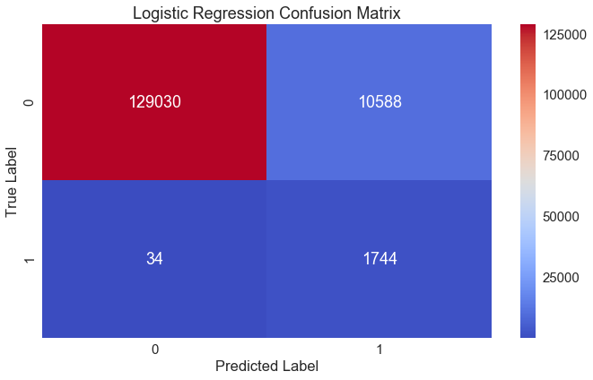

```python
logreg_conf_mat = confusion_matrix(y_test,y_pred)
fig, ax = plt.subplots(figsize=(10,6))
ax = sns.heatmap(logreg_conf_mat,annot=True,cmap='coolwarm',fmt='.0f')
ax.set_title('Logistic Regression Confusion Matrix')
ax.set_ylabel('True Label')
ax.set_xlabel('Predicted Label')
```

When looking at the confusion matrix, we can see that this model predicting very well for actual cancelled flights (98%), but it misclassifies non-cancelled flights with 7% ([10588/(129030+10588)]. It appears that this model is predicting too many flights as cancelled so it decreases the model's precision. But for our case, `sensivity (recall) (TP/(TP+FN) is more important than preicision` because **we don't want to misclassify the actual Cancelled flights**.

```python
import pickle
logreg_model_pickled = pickle.dumps(logreg_model)
```

**k-Nearest Neighbor**

```python
from sklearn.neighbors import KNeighborsClassifier
```

Normally, we would loop through multiple different numbers of neighbors to use when creating a k-NN classifier and determine which value is optimal. To constrain the scope of this project, we will just use a value of 5 for now.

```python
knn_model = KNeighborsClassifier(n_neighbors=5)
knn_model.fit(X_train,y_train)
```

```
KNeighborsClassifier(algorithm='auto', leaf_size=30, metric='minkowski',
           metric_params=None, n_jobs=1, n_neighbors=5, p=2,
           weights='uniform')
```

```python
evaluation_scores(knn_model, X_train, y_train, kfold)
```

```
Mean Accuracy            : 0.9937674939491735
Mean Log Loss            : -0.05620718136992211
Mean Area Under ROC Curve: 0.9704165472044975
```

```python
knn_model.score(X_test,y_test)
```

```
0.99402387620583321
```

The test accuracy is again similar to the train set, so the model does appear to generalize well.

```python
y_pred_knn = knn_model.predict(X_test)
```

```python
print(classification_report(y_test, y_pred_knn))
```

```
             precision    recall  f1-score   support

          0       1.00      1.00      1.00    139618
          1       0.76      0.77      0.76      1778

avg / total       0.99      0.99      0.99    141396
```

```
Text(0.5,5.24,'Predicted Label')
```

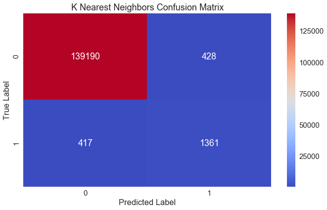

```python
knn_cm = confusion_matrix(y_test,y_pred_knn)
fig, ax = plt.subplots(figsize=(10,6))
ax = sns.heatmap(knn_cm,annot=True,cmap='coolwarm',fmt='.0f')
ax.set_title('K Nearest Neighbors Confusion Matrix')
ax.set_ylabel('True Label')
ax.set_xlabel('Predicted Label')
```

**Random Forest**

Next, we will build a model using a random forest classifier.

```python
from sklearn.ensemble import RandomForestClassifier
```

```python
rand_forest_model = RandomForestClassifier(n_estimators = 30, random_state=33, class_weight='balanced' )
rand_forest_model.fit(X_train, y_train)
```

```
RandomForestClassifier(bootstrap=True, class_weight='balanced',
            criterion='gini', max_depth=None, max_features='auto',
            max_leaf_nodes=None, min_impurity_decrease=0.0,
            min_impurity_split=None, min_samples_leaf=1,
            min_samples_split=2, min_weight_fraction_leaf=0.0,
            n_estimators=30, n_jobs=1, oob_score=False, random_state=33,
            verbose=0, warm_start=False)
```

```python
evaluation_scores(rand_forest_model, X_train, y_train, kfold)
```

```
Mean Accuracy            : 0.9998108147565065
Mean Log Loss            : -0.002289360172238722
Mean Area Under ROC Curve: 0.9987521808199131
```

The random forest produced a much higher accuracy than both the logistic regression, and k-NN model. On the other hand, Log loss and Area under ROC curve metrics are also the best so far.

Let's take a look at how this model generalizes to the test set.

```python
rand_forest_model.score(X_test,y_test)
```

```
0.99981611926787184
```

The test accuracy pretty close to the train set, so the model does appear to generalize well, too.

```python
y_pred_randomforest = rand_forest_model.predict(X_test)
```

```python
print(classification_report(y_test, y_pred_randomforest))
```

```
             precision    recall  f1-score   support

          0       1.00      1.00      1.00    139618
          1       1.00      0.99      0.99      1778

avg / total       1.00      1.00      1.00    141396
```

```
Text(0.5,5.24,'Predicted Label')
```

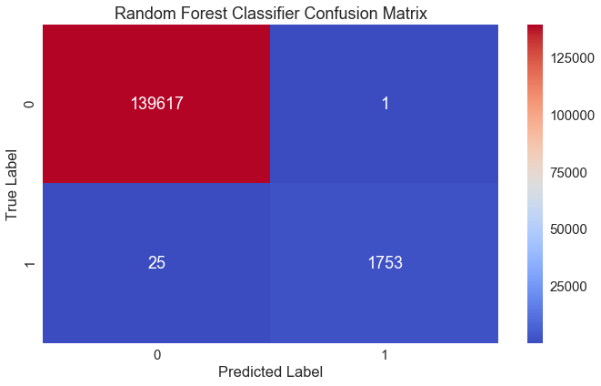

```python
rand_forest_conf_matrx  =  confusion_matrix(y_test, y_pred_randomforest)
fig, ax = plt.subplots(figsize=(10,6))
ax = sns.heatmap(rand_forest_conf_matrx, annot=True,cmap='coolwarm',fmt='.0f')
ax.set_title('Random Forest Classifier Confusion Matrix')
ax.set_ylabel('True Label')
ax.set_xlabel('Predicted Label')
```

When looking at the confusion matrix, it is clear that this model is predicting perfect the flights which is not cancelled . At the same time, actual cancelled flights were predicted very well too. The recall rate for Cancell flight is 98% which is pretty good.

**Adaboost**

```python
from sklearn.ensemble import AdaBoostClassifier
from sklearn.tree import DecisionTreeClassifier
ada_clf = AdaBoostClassifier(DecisionTreeClassifier(max_depth=1), n_estimators=200,
            algorithm="SAMME.R", learning_rate=0.5)
ada_clf.fit(X_train, y_train)
```

```
AdaBoostClassifier(algorithm='SAMME.R',
          base_estimator=DecisionTreeClassifier(class_weight=None, criterion='gini', max_depth=1,
            max_features=None, max_leaf_nodes=None,
            min_impurity_decrease=0.0, min_impurity_split=None,
            min_samples_leaf=1, min_samples_split=2,
            min_weight_fraction_leaf=0.0, presort=False, random_state=None,
            splitter='best'),
          learning_rate=0.5, n_estimators=200, random_state=None)
```

```python
y_pred_ada = ada_clf.predict(X_test)
```

```python
print (classification_report(y_test, y_pred_ada))
```

```
             precision    recall  f1-score   support

          0       1.00      1.00      1.00    139618
          1       1.00      1.00      1.00      1778

avg / total       1.00      1.00      1.00    141396
```

```
Text(0.5,5.24,'Predicted Label')
```

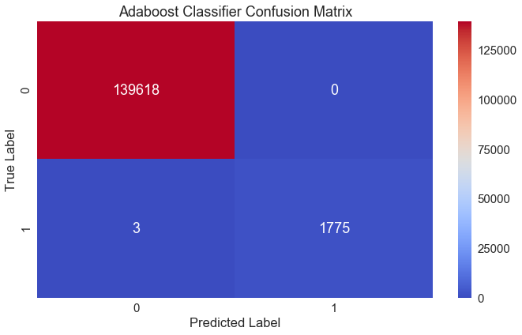

```python
adaboost_conf_matrx  =  confusion_matrix(y_test,y_pred_ada)
fig, ax = plt.subplots(figsize=(10,6))
ax = sns.heatmap(adaboost_conf_matrx, annot=True,cmap='coolwarm',fmt='.0f')
ax.set_title('Adaboost Classifier Confusion Matrix')
ax.set_ylabel('True Label')
ax.set_xlabel('Predicted Label')
```

**Gradient Boost**

```python
from sklearn.ensemble import GradientBoostingClassifier
```

```python
params = {'n_estimators': 200, 'max_depth': 6,'learning_rate': 0.1}
xgboost_clf = GradientBoostingClassifier(learning_rate=0.1, n_estimators=100, max_depth=3, min_samples_split=2, min_samples_leaf=1, subsample=1, random_state=33)

xgboost_clf.fit(X_train, y_train)
```

```
GradientBoostingClassifier(criterion='friedman_mse', init=None,
              learning_rate=0.1, loss='deviance', max_depth=3,
              max_features=None, max_leaf_nodes=None,
              min_impurity_decrease=0.0, min_impurity_split=None,
              min_samples_leaf=1, min_samples_split=2,
              min_weight_fraction_leaf=0.0, n_estimators=100,
              presort='auto', random_state=33, subsample=1, verbose=0,
              warm_start=False)
```

```python
y_pred_xgboost = xgboost_clf.predict(X_test)
```

```python
print (classification_report(y_test, y_pred_xgboost))
```

```
             precision    recall  f1-score   support

          0       1.00      1.00      1.00    139618
          1       1.00      1.00      1.00      1778

avg / total       1.00      1.00      1.00    141396
```

```
Text(0.5,5.24,'Predicted Label')
```

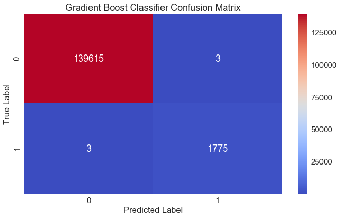

```python
xgboost_conf_matrx  =  confusion_matrix(y_test,y_pred_xgboost)
fig, ax = plt.subplots(figsize=(10,6))
ax = sns.heatmap(xgboost_conf_matrx, annot=True,cmap='coolwarm',fmt='.0f')
ax.set_title('Gradient Boost Classifier Confusion Matrix')
ax.set_ylabel('True Label')
ax.set_xlabel('Predicted Label')
```